# Tree Models Exercise

Tree Models Exercise — USDA · NRCS · National Soil Survey Center

STAT2020

2026-02-26

# 1 Setup: Load Packages

Install any missing packages before running. All packages should be available on CRAN.

```r
library(ggplot2)      # visualization
library(sf)           # spatial data
library(mapview)      # interactive maps
library(corrplot)     # correlation matrix plot
library(rpart)        # CART (recursive partitioning)
library(rpart.plot)   # rpart visualization
library(randomForest) # classic random forest
library(ranger)       # fast random forest
library(caret)        # cross-validation framework
library(vip)          # variable importance plots
library(pdp)          # partial dependence plots
library(Boruta)          # feature selection
library(tidyverse)       # data wrangling and ggplot2
library(fastshap)        # SHAP values for any ML model
library(shapviz)         # SHAP visualisation (beeswarm, waterfall)
library(ggbeeswarm)      # beeswarm geometry for SHAP plots
library(quantregForest)  # Quantile Regression Forest
library(CAST)            # kNNDM CV and Area of Applicability
```

# 2 Part 1 — Explore the Dataset

## 2.1 Background

We use a soil survey transect dataset from **West Virginia** throughout this exercise. The dataset contains field-collected pedon observations linked to environmental covariates derived from terrain analysis, remote sensing, and climate surfaces — the standard input data structure for digital soil mapping (DSM).

**Response variables used in this exercise:**

| Variable | Type | Description |
| --- | --- | --- |
| `spodint` | Ordered factor | Spodic intensity (0–2) — used for classification |
| `Otot` | Continuous | O horizon thickness (cm) — used for regression and RF |

**Key environmental covariates** include terrain derivatives (DEM, slope, aspect, TWI), Landsat reflectance bands, NDVI, solar radiation, and mean annual rainfall.

## 2.2 Load and Map Data

```r
# Download the WV transect data from GitHub
url <- "https://raw.githubusercontent.com/ncss-tech/stats_for_soil_survey/master/data/logistic/wv_transect_editedforR.csv"
download.file(url, "soildata.csv", mode = "wb")
soildata <- read.csv("soildata.csv", header = TRUE, sep = ",")

# Convert to spatial object for mapping
soildata_sf <- st_as_sf(
  soildata,
  coords = c("x", "y"),
  crs    = 4326
)

# Interactive map of sampling locations
mapview(soildata_sf, zcol = "depth_cm", layer.name = "Soil Depth (cm)")@map
```

[interactive chart not shown]

```r
# Optional: write shapefile for use in GIS
write_sf(soildata_sf, dsn = "soildata.shp")
```

## 2.3 Exploratory Data Analysis

```r
# Reload as flat data frame for modeling
soildata <- read.csv("soildata.csv", header = TRUE, sep = ",")

soildata$spodint  <- ordered(as.factor(soildata$spodint))
soildata$tipmound <- ordered(as.factor(soildata$tipmound))

str(soildata)
```

```
#> 'data.frame':    250 obs. of  50 variables:
#>  $ x           : num  -79.7 -79.7 -79.7 -79.8 -79.7 ...
#>  $ y           : num  38.6 38.6 38.6 38.6 38.6 ...
#>  $ Overtype    : chr  "Hardwood" "Hardwood" "Hardwood" "Hardwood" ...
#>  $ Underconifer: chr  "n" "y" "n" "y" ...
#>  $ Oi          : num  3 4 3 4 3 2 2 2 4 3 ...
#>  $ Oe          : num  0 0 2 4 4 6 4 2 2 4 ...
#>  $ Oa          : num  0 3 0 0 8 0 0 0 7 4 ...
#>  $ Otot        : num  3 7 5 8 15 8 6 4 13 7 ...
#>  $ epipedon    : chr  "ochric" "ochric" "ochric" "ochric" ...
#>  $ spodint     : Ord.factor w/ 5 levels "0"<"0.5"<"1"<..: 1 1 1 1 3 3 3 2 3 1 ...
#>  $ subgroup    : chr  "typic" "typic" "typic" "typic" ...
#>  $ order       : chr  "ultisol" "inceptisol" "ultisol" "inceptisol" ...
#>  $ ps          : chr  "fl" "ls" "fl" "cl" ...
#>  $ drainage    : chr  "wd" "wd" "wd" "wd" ...
```

[output cut: 36 more lines]

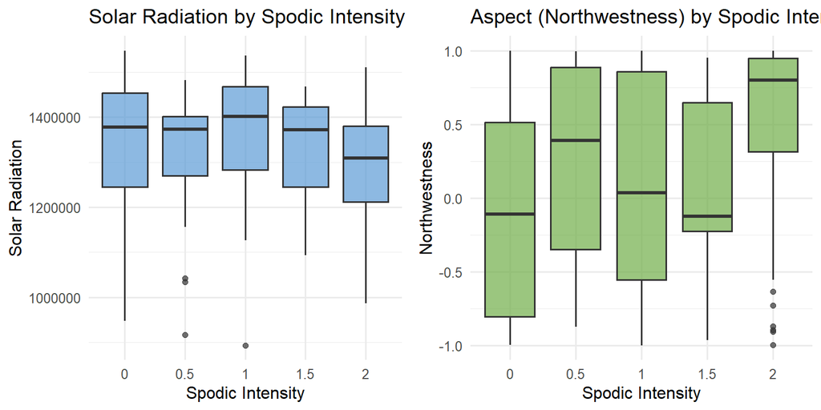

```r
# Spodic intensity vs solar radiation
p1 <- ggplot(soildata, aes(x = spodint, y = solar)) +
  geom_boxplot(fill = "#5b9bd5", alpha = 0.7) +
  labs(x = "Spodic Intensity", y = "Solar Radiation",
       title = "Solar Radiation by Spodic Intensity") +
  theme_minimal(base_size = 12)

# Spodic intensity vs northwestness (aspect proxy)
p2 <- ggplot(soildata, aes(x = spodint, y = northwestn)) +
  geom_boxplot(fill = "#70ad47", alpha = 0.7) +
  labs(x = "Spodic Intensity", y = "Northwestness",
       title = "Aspect (Northwestness) by Spodic Intensity") +
  theme_minimal(base_size = 12)

gridExtra::grid.arrange(p1, p2, ncol = 2)
```

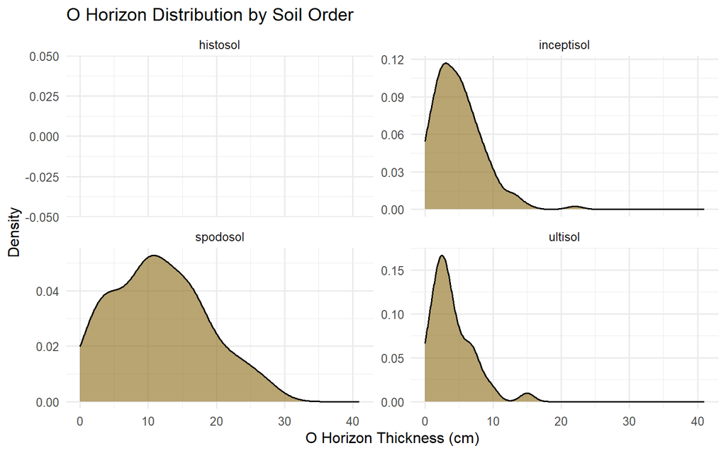

```r
# O horizon thickness by soil order
ggplot(soildata, aes(x = Otot)) +
  geom_density(fill = "#8b6914", alpha = 0.6) +
  facet_wrap(~ order, scales = "free_y") +
  labs(x = "O Horizon Thickness (cm)", y = "Density",
       title = "O Horizon Distribution by Soil Order") +
  theme_minimal(base_size = 12)
```

## 2.4 Correlation Matrix

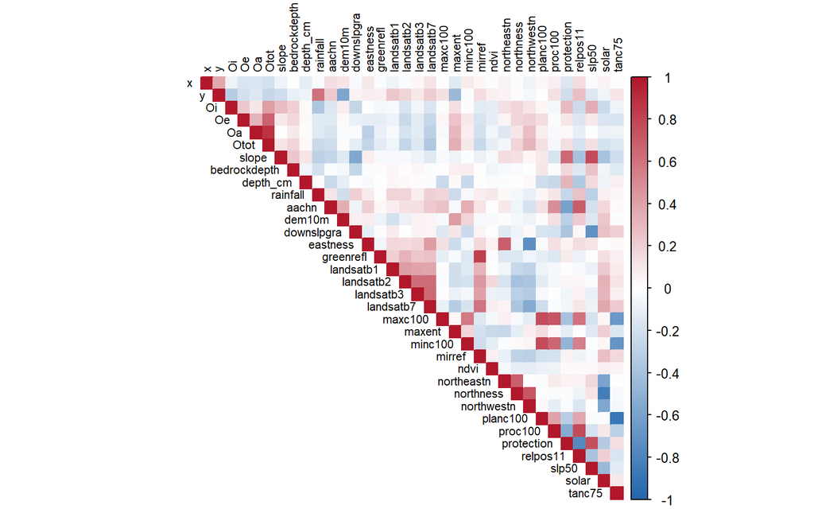

```r
# Select numeric columns only
numeric_vars <- soildata |> dplyr::select(where(is.numeric))

cormatrix <- cor(numeric_vars, use = "pairwise.complete.obs")

corrplot(cormatrix,
         method    = "color",
         type      = "upper",
         tl.cex    = 0.7,
         tl.col    = "black",
         addCoef.col = NULL,
         col       = colorRampPalette(c("#2166ac", "white", "#b2182b"))(200))
```

> **Questions:**  
> 1. Which predictors are highly correlated with each other? What does this imply for covariate selection?  
> 2. Does any predictor show a strong correlation with `depth_cm`?

# 3 Part 2 — Classification Tree: Predicting Spodic Intensity

## 3.1 Theory: Gini Impurity and Information Gain

For classification tasks, CART chooses splits that minimize **node impurity** rather than RSS. Two common impurity measures:

**Gini Impurity** (CART default):
$$G = 1 - \sum_k p_k^2$$
where $p_k$ is the class proportion. A pure node ($G = 0$) contains only one class.

**Entropy** (used by C4.5 / information gain):
$$H = -\sum_k p_k \log_2(p_k)$$

*Example with 80% Spodic / 20% Non-Spodic (binary case):*

- Gini: $G = 1 - (0.8^2 + 0.2^2) = 0.32$
- Entropy: $H = -(0.8 \log_2 0.8 + 0.2 \log_2 0.2) = 0.72$ bits

For an **ordered multi-class** response like `spodint` (levels 0, 0.5, 1, 1.5, 2), CART still uses Gini or entropy but now sums across all five class proportions at each node. The ordered structure is preserved — the tree can learn that intensity level 0 and 0.5 behave similarly while separating from 1.5 and 2.

| Parameter | Default | Effect |
| --- | --- | --- |
| `minsplit` | 20 | minimum observations in a node to attempt a split |
| `minbucket` | `minsplit/3` ≈ 7 | minimum observations allowed in a terminal leaf |
| `cp` | 0.01 | minimum proportional RSS improvement required to accept a split |
| `maxdepth` | 30 | maximum tree depth from root to terminal node |
| `maxcompete` | 4 | number of competitor splits reported per node |
| `xval` | 10 | number of cross-validation folds for CP table |

> **Tip:** For most soil classification tasks, Gini and entropy produce nearly identical trees. Gini is faster (no logarithm). Use entropy when class probabilities matter more than just the predicted class label.

## 3.2 Data Preparation

```r
# Fresh read — classification task
soildata <- read.csv("soildata.csv", header = TRUE, sep = ",")

# Keep spodint as an ordered factor (0 < 0.5 < 1 < 1.5 < 2)
soildata$spodint  <- ordered(as.factor(soildata$spodint))
soildata$tipmound <- ordered(as.factor(soildata$tipmound))

# Class distribution across all 5 intensity levels
table(soildata$spodint)
```

```
#>
#>   0 0.5   1 1.5   2
#>  88  21  65   6  70
```

```r
set.seed(42)
# 70/30 split — aligns with 006-treemodels approach
datasplit <- sample(nrow(soildata), nrow(soildata) * 0.7)
train_sp  <- soildata[ datasplit, ]
test_sp   <- soildata[-datasplit, ]

xvars_class <- c(
  "rainfall", "geology", "aachn", "dem10m", "downslpgra", "eastness",
  "greenrefl", "landsatb1", "landsatb2", "landsatb3", "landsatb7",
  "maxc100", "maxent", "minc100", "mirref", "ndvi",
  "northeastn", "northness", "northwestn", "planc100", "proc100",
  "protection", "relpos11", "slp50", "solar", "tanc75"
)
```

## 3.3 Model 1: Multi-Class spodint

We start by predicting **all five spodic intensity classes** (0, 0.5, 1, 1.5, 2) directly. This mirrors the original field measurement and preserves the full gradient of spodic expression.

```r
spodintmodel <- rpart(
  spodint ~ rainfall + geology + aachn + dem10m + downslpgra + eastness + greenrefl +
    landsatb1 + landsatb2 + landsatb3 + landsatb7 + maxc100 + maxent + minc100 +
    mirref + ndvi + northeastn + northness + northwestn + planc100 + proc100 +
    protection + relpos11 + slp50 + solar + tanc75,
  data   = train_sp,
  method = "class"
)

# Text summary
# spodintmodel
```

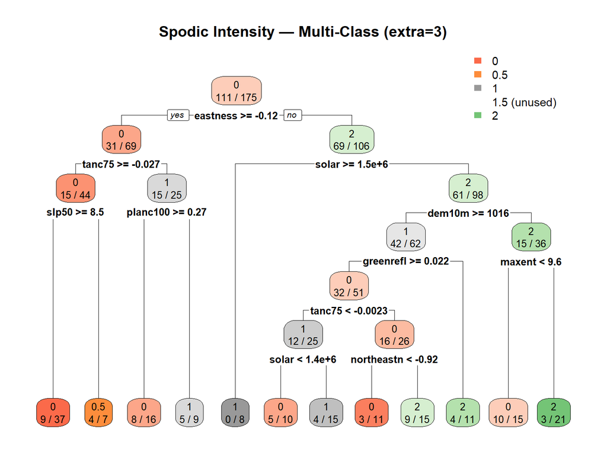

```r
# Misclassification rate at node (incorrect / total in node)
rpart.plot(spodintmodel, extra = 3,
           main = "Spodic Intensity — Multi-Class (extra=3)")
```

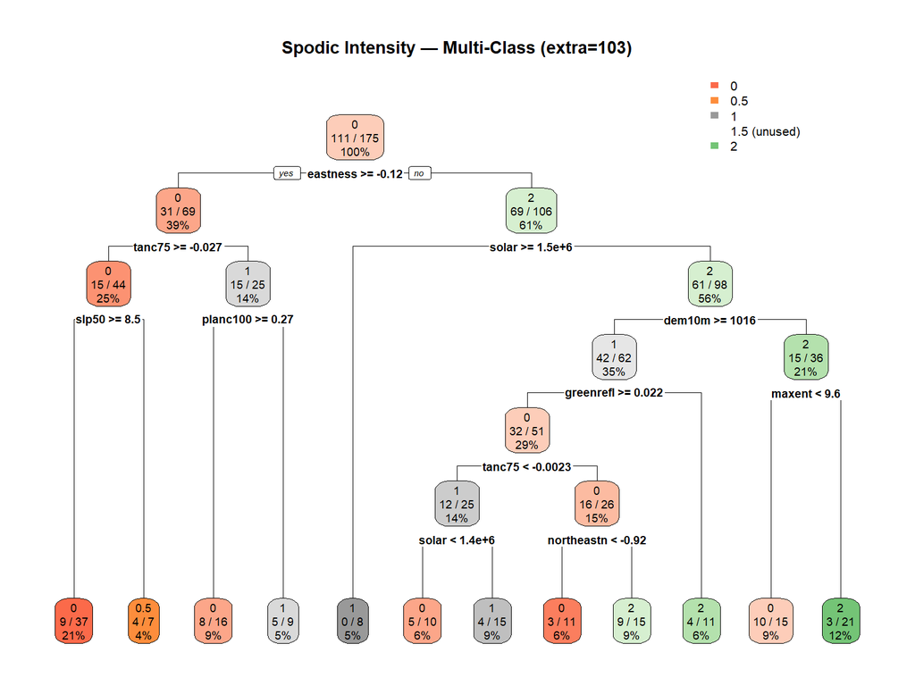

```r
# Adding 100 shows percentage of observations in each node
rpart.plot(spodintmodel, extra = 103,
           main = "Spodic Intensity — Multi-Class (extra=103)")
```

> Notice that terminal nodes display spodic intensity classes 0–2. The tree must learn to separate five classes using the same covariates, making this a harder problem than binary classification.

## 3.4 Model 2: Binary (Spodic / Non-Spodic)

An alternative framing: collapse the intensity scale into **spodic vs non-spodic**, analogous to Nauman et al. (2015). Intensity ≤ 0.5 = non-spodic; ≥ 1 = spodic. This simplifies the prediction task but loses information about degree of expression.

```r
# Recode spodint into binary response
index  <- c(0, 0.5, 1, 1.5, 2)
values <- c("nonspodic", "nonspodic", "spodic", "spodic", "spodic")
soildata$spo_binary  <- as.factor(values[match(soildata$spodint, index)])
train_sp$spo_binary  <- as.factor(values[match(train_sp$spodint, index)])
test_sp$spo_binary   <- as.factor(values[match(test_sp$spodint, index)])

spodintmodel2 <- rpart(
  spo_binary ~ rainfall + geology + aachn + dem10m + downslpgra + eastness + greenrefl +
    landsatb1 + landsatb2 + landsatb3 + landsatb7 + maxc100 + maxent + minc100 +
    mirref + ndvi + northeastn + northness + northwestn + planc100 + proc100 +
    protection + relpos11 + slp50 + solar + tanc75,
  data   = train_sp,
  method = "class", parms = list(split = "gini")
)
spodintmodel3 <- rpart(
  spo_binary ~ rainfall + geology + aachn + dem10m + downslpgra + eastness + greenrefl +
    landsatb1 + landsatb2 + landsatb3 + landsatb7 + maxc100 + maxent + minc100 +
    mirref + ndvi + northeastn + northness + northwestn + planc100 + proc100 +
    protection + relpos11 + slp50 + solar + tanc75,
  data   = train_sp,
  method = "class", parms = list(split = "information")
)
spodintmodel2
```

```
#> n= 175
#>
#> node), split, n, loss, yval, (yprob)
#>       * denotes terminal node
#>
#>  1) root 175 77 spodic (0.44000000 0.56000000)
#>    2) eastness>=-0.1275925 70 26 nonspodic (0.62857143 0.37142857)
#>      4) ndvi< 0.7836855 27  4 nonspodic (0.85185185 0.14814815) *
#>      5) ndvi>=0.7836855 43 21 spodic (0.48837209 0.51162791)
#>       10) minc100< 0.04657755 32 13 nonspodic (0.59375000 0.40625000)
#>         20) ndvi>=0.816858 12  1 nonspodic (0.91666667 0.08333333) *
#>         21) ndvi< 0.816858 20  8 spodic (0.40000000 0.60000000)
#>           42) aachn>=31.8804 9  3 nonspodic (0.66666667 0.33333333) *
#>           43) aachn< 31.8804 11  2 spodic (0.18181818 0.81818182) *
#>       11) minc100>=0.04657755 11  2 spodic (0.18181818 0.81818182) *
#>    3) eastness< -0.1275925 105 33 spodic (0.31428571 0.68571429)
#>      6) landsatb7>=0.0483566 28 13 nonspodic (0.53571429 0.46428571)
#>       12) northeastn< -0.9625365 11  2 nonspodic (0.81818182 0.18181818) *
#>       13) northeastn>=-0.9625365 17  6 spodic (0.35294118 0.64705882) *
#>      7) landsatb7< 0.0483566 77 18 spodic (0.23376623 0.76623377) *
```

```r
spodintmodel3
```

```
#> n= 175
#>
#> node), split, n, loss, yval, (yprob)
#>       * denotes terminal node
#>
#>   1) root 175 77 spodic (0.44000000 0.56000000)
#>     2) eastness>=-0.1275925 70 26 nonspodic (0.62857143 0.37142857)
#>       4) ndvi< 0.7836855 27  4 nonspodic (0.85185185 0.14814815) *
#>       5) ndvi>=0.7836855 43 21 spodic (0.48837209 0.51162791)
#>        10) minc100< 0.04657755 32 13 nonspodic (0.59375000 0.40625000)
#>          20) ndvi>=0.816858 12  1 nonspodic (0.91666667 0.08333333) *
#>          21) ndvi< 0.816858 20  8 spodic (0.40000000 0.60000000)
#>            42) aachn>=31.8804 9  3 nonspodic (0.66666667 0.33333333) *
#>            43) aachn< 31.8804 11  2 spodic (0.18181818 0.81818182) *
#>        11) minc100>=0.04657755 11  2 spodic (0.18181818 0.81818182) *
#>     3) eastness< -0.1275925 105 33 spodic (0.31428571 0.68571429)
#>       6) mirref>=0.01651805 94 33 spodic (0.35106383 0.64893617)
#>        12) northness>=-0.8723 85 33 spodic (0.38823529 0.61176471)
#>          24) landsatb7>=0.0483566 23  8 nonspodic (0.65217391 0.34782609) *
#>          25) landsatb7< 0.0483566 62 18 spodic (0.29032258 0.70967742)
#>            50) downslpgra>=33.43825 43 17 spodic (0.39534884 0.60465116)
#>             100) landsatb2< 0.0519325 9  2 nonspodic (0.77777778 0.22222222) *
#>             101) landsatb2>=0.0519325 34 10 spodic (0.29411765 0.70588235)
#>               202) landsatb2>=0.0592247 8  3 nonspodic (0.62500000 0.37500000) *
#>               203) landsatb2< 0.0592247 26  5 spodic (0.19230769 0.80769231)
#>                 406) geology=Dhs 7  3 nonspodic (0.57142857 0.42857143) *
#>                 407) geology=Dch 19  1 spodic (0.05263158 0.94736842) *
#>            51) downslpgra< 33.43825 19  1 spodic (0.05263158 0.94736842) *
#>        13) northness< -0.8723 9  0 spodic (0.00000000 1.00000000) *
#>       7) mirref< 0.01651805 11  0 spodic (0.00000000 1.00000000) *
```

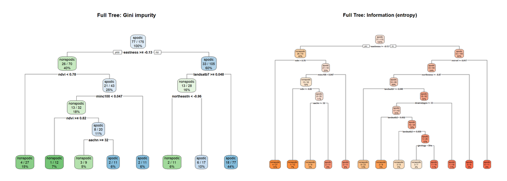

```r
par(mfrow = c(1, 2))
rpart.plot(spodintmodel2, extra = 103, box.palette = "GnBu",
           main = "Full Tree: Gini impurity")
rpart.plot(spodintmodel3, extra = 103, box.palette = "OrRd",
           main = "Full Tree: Information (entropy)")
```

```r
par(mfrow = c(1, 1))
```

The two criteria build different full trees. Check the structure:

```r
# Node and split counts for each criterion
gini_leaves <- sum(spodintmodel2$frame$var == "<leaf>")
info_leaves <- sum(spodintmodel3$frame$var == "<leaf>")

cat(sprintf("Gini      — terminal nodes: %d,  total nodes: %d\n",
            gini_leaves, nrow(spodintmodel2$frame)))
```

```
#> Gini      — terminal nodes: 8,  total nodes: 15
```

```r
cat(sprintf("Entropy   — terminal nodes: %d,  total nodes: %d\n",
            info_leaves, nrow(spodintmodel3$frame)))
```

```
#> Entropy   — terminal nodes: 13,  total nodes: 25
```

```r
# Root and top splits for each
cat("\n--- Gini: top 3 splits ---\n")
```

```
#>
#> --- Gini: top 3 splits ---
```

```r
print(spodintmodel2$frame[spodintmodel2$frame$var != "<leaf>",
                           c("var", "n", "dev"), drop = FALSE][1:min(3, sum(spodintmodel2$frame$var != "<leaf>")), ])
```

```
#>        var   n dev
#> 1 eastness 175  77
#> 2     ndvi  70  26
#> 5  minc100  43  21
```

```r
cat("\n--- Entropy: top 3 splits ---\n")
```

```
#>
#> --- Entropy: top 3 splits ---
```

```r
print(spodintmodel3$frame[spodintmodel3$frame$var != "<leaf>",
                           c("var", "n", "dev"), drop = FALSE][1:min(3, sum(spodintmodel3$frame$var != "<leaf>")), ])
```

```
#>        var   n dev
#> 1 eastness 175  77
#> 2     ndvi  70  26
#> 5  minc100  43  21
```

```r
# Visualise where the splits diverge: compare paths to all terminal nodes
gini_path <- path.rpart(spodintmodel2, nodes = as.integer(
  row.names(spodintmodel2$frame[spodintmodel2$frame$var == "<leaf>", ])),
  print.it = FALSE)
info_path <- path.rpart(spodintmodel3, nodes = as.integer(
  row.names(spodintmodel3$frame[spodintmodel3$frame$var == "<leaf>", ])),
  print.it = FALSE)

# Summarise: which variables appear in each tree's splits
gini_vars <- unique(as.character(
  spodintmodel2$frame$var[spodintmodel2$frame$var != "<leaf>"]))
info_vars <- unique(as.character(
  spodintmodel3$frame$var[spodintmodel3$frame$var != "<leaf>"]))

cat("Variables used — Gini only:      ", paste(setdiff(gini_vars, info_vars), collapse = ", "), "\n")
```

```
#> Variables used — Gini only:       northeastn
```

```r
cat("Variables used — Entropy only:   ", paste(setdiff(info_vars, gini_vars), collapse = ", "), "\n")
```

```
#> Variables used — Entropy only:    mirref, northness, downslpgra, landsatb2, geology
```

```r
cat("Variables used — both criteria:  ", paste(intersect(gini_vars, info_vars), collapse = ", "), "\n")
```

```
#> Variables used — both criteria:   eastness, ndvi, minc100, aachn, landsatb7
```

Now prune both with the 1-SE rule:

```r
cp_1se_gini <- {
  tbl <- spodintmodel2$cptable
  xe  <- tbl[, "xerror"]; xs <- tbl[, "xstd"]
  mi  <- which.min(xe)
  tbl[min(which(xe <= xe[mi] + xs[mi])), "CP"]
}
cp_1se_info <- {
  tbl <- spodintmodel3$cptable
  xe  <- tbl[, "xerror"]; xs <- tbl[, "xstd"]
  mi  <- which.min(xe)
  tbl[min(which(xe <= xe[mi] + xs[mi])), "CP"]
}

pruned_gini <- prune(spodintmodel2, cp = cp_1se_gini)
pruned_info <- prune(spodintmodel3, cp = cp_1se_info)

cat(sprintf("Pruned Gini    — terminal nodes: %d  (from %d)\n",
            sum(pruned_gini$frame$var == "<leaf>"), gini_leaves))
```

```
#> Pruned Gini    — terminal nodes: 2  (from 8)
```

```r
cat(sprintf("Pruned Entropy — terminal nodes: %d  (from %d)\n",
            sum(pruned_info$frame$var == "<leaf>"), info_leaves))
```

```
#> Pruned Entropy — terminal nodes: 2  (from 13)
```

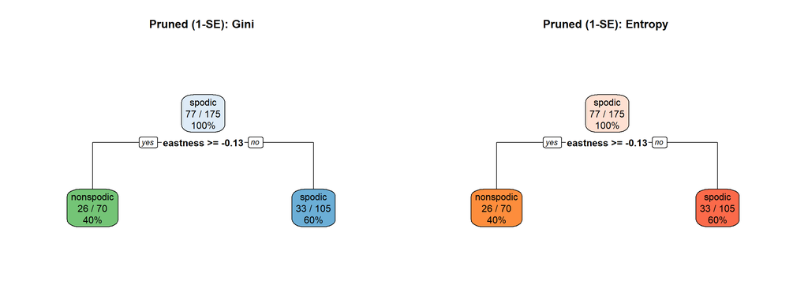

```r
par(mfrow = c(1, 2))
rpart.plot(pruned_gini, extra = 103, box.palette = "GnBu",
           main = "Pruned (1-SE): Gini")
rpart.plot(pruned_info, extra = 103, box.palette = "OrRd",
           main = "Pruned (1-SE): Entropy")
```

```r
par(mfrow = c(1, 1))
```

```r
pred_gini <- predict(pruned_gini, newdata = test_sp, type = "class")
pred_info <- predict(pruned_info, newdata = test_sp, type = "class")

acc_gini <- mean(pred_gini == test_sp$spo_binary)
acc_info <- mean(pred_info == test_sp$spo_binary)

cat(sprintf("Test accuracy — Gini pruned:    %.4f\n", acc_gini))
```

```
#> Test accuracy — Gini pruned:    0.7067
```

```r
cat(sprintf("Test accuracy — Entropy pruned: %.4f\n", acc_info))
```

```
#> Test accuracy — Entropy pruned: 0.7067
```

```r
cat(sprintf("Difference:                     %.4f\n", abs(acc_gini - acc_info)))
```

```
#> Difference:                     0.0000
```

> After 1-SE pruning, the deep noise-driven branches are removed from both trees, leaving only splits with a large, consistent impurity reduction — strong enough that Gini and entropy rank them identically. The pruned trees typically share the same structure and produce the same (or within rounding identical) test accuracy.

> **Notice that several of the splits changed compared to the multi-class model. Which model do you think will perform better? Why?**

## 3.5 CP Comparison and Pruning

The `printcp()` function generates the cost-complexity table: CP value, relative error, 10-fold cross-validation error (`xerror`), and its standard error (`xstd`). Use `plotcp()` to visualise the tradeoff between tree size and CV error.

```r
# CP tables for both models
cat("=== Multi-class spodint CP table ===\n")
```

```
#> === Multi-class spodint CP table ===
```

```r
printcp(spodintmodel)
```

```
#>
#> Classification tree:
#> rpart(formula = spodint ~ rainfall + geology + aachn + dem10m +
#>     downslpgra + eastness + greenrefl + landsatb1 + landsatb2 +
#>     landsatb3 + landsatb7 + maxc100 + maxent + minc100 + mirref +
#>     ndvi + northeastn + northness + northwestn + planc100 + proc100 +
#>     protection + relpos11 + slp50 + solar + tanc75, data = train_sp,
#>     method = "class")
#>
#> Variables actually used in tree construction:
#> [1] dem10m     eastness   greenrefl  maxent     northeastn planc100   slp50
#> [8] solar      tanc75
#>
#> Root node error: 111/175 = 0.63429
#>
#> n= 175
#>
#>         CP nsplit rel error  xerror     xstd
#> 1 0.099099      0   1.00000 1.00000 0.057400
#> 2 0.072072      1   0.90090 1.09910 0.054762
#> 3 0.045045      2   0.82883 1.04505 0.056340
#> 4 0.036036      4   0.73874 1.00901 0.057205
#> 5 0.027027      6   0.66667 0.98198 0.057762
#> 6 0.018018      7   0.63964 0.98198 0.057762
#> 7 0.015015      8   0.62162 0.99099 0.057585
#> 8 0.010000     11   0.57658 1.00000 0.057400
```

```r
cat("\n=== Binary spodic/nonspodic CP table ===\n")
```

```
#>
#> === Binary spodic/nonspodic CP table ===
```

```r
printcp(spodintmodel2)
```

```
#>
#> Classification tree:
#> rpart(formula = spo_binary ~ rainfall + geology + aachn + dem10m +
#>     downslpgra + eastness + greenrefl + landsatb1 + landsatb2 +
#>     landsatb3 + landsatb7 + maxc100 + maxent + minc100 + mirref +
#>     ndvi + northeastn + northness + northwestn + planc100 + proc100 +
#>     protection + relpos11 + slp50 + solar + tanc75, data = train_sp,
#>     method = "class", parms = list(split = "gini"))
#>
#> Variables actually used in tree construction:
#> [1] aachn      eastness   landsatb7  minc100    ndvi       northeastn
#>
#> Root node error: 77/175 = 0.44
#>
#> n= 175
#>
#>         CP nsplit rel error  xerror     xstd
#> 1 0.233766      0   1.00000 1.00000 0.085280
#> 2 0.045455      1   0.76623 0.84416 0.083012
#> 3 0.038961      6   0.53247 0.90909 0.084165
#> 4 0.010000      7   0.49351 0.90909 0.084165
```

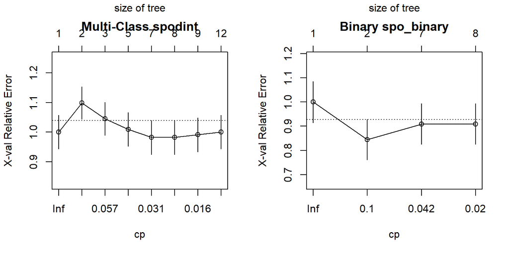

```r
par(mfrow = c(1, 2))
plotcp(spodintmodel,  main = "Multi-Class spodint")
plotcp(spodintmodel2, main = "Binary spo_binary")
```

```r
par(mfrow = c(1, 1))
```

```r
# Automated 1-SE rule for both models
cp_1se_fn <- function(model) {
  tbl     <- model$cptable
  xerr    <- tbl[, "xerror"]
  xstd    <- tbl[, "xstd"]
  min_idx <- which.min(xerr)
  thresh  <- xerr[min_idx] + xstd[min_idx]
  tbl[min(which(xerr <= thresh)), "CP"]
}

cp1 <- cp_1se_fn(spodintmodel)
cp2 <- cp_1se_fn(spodintmodel2)
cp3 <- cp_1se_fn(spodintmodel3)

cat(sprintf("1-SE CP — multi-class: %.6f\n", cp1))
```

```
#> 1-SE CP — multi-class: 0.099099
```

```r
cat(sprintf("1-SE CP — binary:      %.6f\n", cp2))
```

```
#> 1-SE CP — binary:      0.045455
```

```r
cat(sprintf("1-SE CP — binary:      %.6f\n", cp3))
```

```
#> 1-SE CP — binary:      0.045455
```

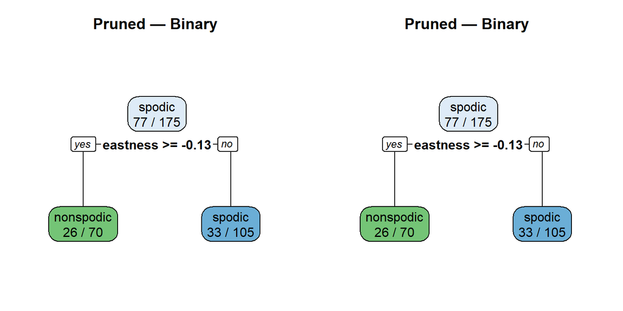

```r
pruned_mc  <- prune(spodintmodel,  cp = cp1)
pruned_bin1 <- prune(spodintmodel2, cp = cp2)
pruned_bin2 <- prune(spodintmodel3, cp = cp3)
par(mfrow = c(1, 2), mar = c(1, 1, 3, 1))
# rpart.plot(pruned_mc,  extra = 3, box.palette = "Greens", main = "Pruned — Multi-Class")
rpart.plot(pruned_bin1, extra = 3, box.palette = "GnBu",   main = "Pruned — Binary")
rpart.plot(pruned_bin2, extra = 3, box.palette = "GnBu",   main = "Pruned — Binary")
```

```r
par(mfrow = c(1, 1))
```

## 3.6 Confusion Matrix Comparison

Split-sample validation using the held-out 30% test set:

```r
# Multi-class predictions
pred_mc  <- predict(pruned_mc,  newdata = test_sp, type = "class")
cm_mc    <- confusionMatrix(pred_mc, test_sp$spodint, mode = "everything")

# Binary predictions
pred_bin <- predict(pruned_bin1, newdata = test_sp, type = "class")
cm_bin   <- confusionMatrix(pred_bin, test_sp$spo_binary, mode = "everything")

# Summary
results_tbl <- data.frame(
  Model    = c("Multi-Class (5 levels)", "Binary (spodic/nonspodic)"),
  Accuracy = round(c(cm_mc$overall["Accuracy"],  cm_bin$overall["Accuracy"]), 4),
  Kappa    = round(c(cm_mc$overall["Kappa"],     cm_bin$overall["Kappa"]),    4)
)
print(results_tbl)
```

```
#>                       Model Accuracy  Kappa
#> 1    Multi-Class (5 levels)   0.3200 0.0000
#> 2 Binary (spodic/nonspodic)   0.7067 0.3956
```

```r
cat("--- Multi-Class Confusion Matrix (rows=observed, cols=predicted) ---\n")
```

```
#> --- Multi-Class Confusion Matrix (rows=observed, cols=predicted) ---
```

```r
print(cm_mc$table)
```

```
#>           Reference
#> Prediction  0 0.5  1 1.5  2
#>        0   24   8 18   2 23
#>        0.5  0   0  0   0  0
#>        1    0   0  0   0  0
#>        1.5  0   0  0   0  0
#>        2    0   0  0   0  0
```

```r
cat("\n--- Binary Confusion Matrix ---\n")
```

```
#>
#> --- Binary Confusion Matrix ---
```

```r
print(cm_bin$table)
```

```
#>            Reference
#> Prediction  nonspodic spodic
#>   nonspodic        20     10
#>   spodic           12     33
```

> **Why does the binary model outperform the multi-class model?**  
> The multi-class tree must separate five classes simultaneously with the same covariates. The rarest intermediate classes (0.5, 1.5) are often misclassified because the training signal is weak. Collapsing to binary removes this ambiguity — the decision boundary between spodic and non-spodic is more environmentally consistent than the boundaries between adjacent intensity levels.

> **Questions:**  
> 1. What was the misclassification rate for each model (root node error × xerror × 100)?  
> 2. Which intensity levels are most commonly confused in the multi-class model? Does this make pedological sense?  
> 3. What are the practical implications of misclassifying a spodic site as non-spodic in a soil survey context?  
> 4. Consider treating `spodint` as numeric (0–2) and building a regression tree. What would a leaf mean of 1.0 tell you about the observations in that node?

# 4 Part 3 — Regression Tree: Predicting O Horizon Thickness

## 4.1 Theory: How CART Splits

A **regression tree** recursively partitions the feature space into rectangular regions based on binary splits. At each node, CART evaluates every candidate split $(j, t)$ — feature $j$ at threshold $t$ — and selects the one that maximally reduces the **Residual Sum of Squares (RSS)**:

$$\Delta RSS = RSS_{\text{parent}} -
\left[ RSS_{\text{left}} + RSS_{\text{right}} \right]$$

Within each leaf, the prediction is the mean of all training samples:
$$\hat{y}_{\text{leaf}} =
\frac{1}{N_{\text{leaf}}} \sum_{i \in \text{leaf}} y_i$$

This greedy, top-down algorithm is implemented in R as `rpart()` with `method = "anova"`.

## 4.2 Build and Inspect Tree

```r
set.seed(42)
idx <- createDataPartition(soildata$Otot, p = 0.70, list = FALSE)
cal <- soildata[ idx, ]
val <- soildata[-idx, ]

cat("Calibration samples:", nrow(cal), "\n")
```

```
#> Calibration samples: 177
```

```r
cat("Validation samples: ", nrow(val), "\n")
```

```
#> Validation samples:  73
```

```r
# Define covariate names (reused throughout exercise)
xvars_terrain <- c(
  "rainfall", "dem10m", "downslpgra", "eastness", "greenrefl",
  "landsatb1", "landsatb2", "landsatb3", "landsatb7",
  "maxc100", "maxent", "minc100", "mirref", "ndvi",
  "northeastn", "northness", "northwestn", "planc100",
  "proc100", "protection", "relpos11", "slp50", "solar", "tanc75"
)

tree_full <- rpart(
  formula = as.formula(paste("Otot ~", paste(xvars_terrain, collapse = " + "))),
  data    = cal,
  method  = "anova",
  control = rpart.control(cp = 0, minsplit = 10, minbucket = 5)
)

print(tree_full)
```

```
#> n= 177
#>
#> node), split, n, deviance, yval
#>       * denotes terminal node
#>
#>   1) root 177 6714.282000  6.8163840
#>     2) landsatb7>=0.04194205 109 1825.688000  4.6743120
#>       4) relpos11>=0.6906915 27  183.166700  2.0555560
#>         8) maxc100< 0.532425 21   52.952380  1.1190480
#>          16) dem10m< 1076.515 13    7.076923  0.3846154
#>            32) landsatb1< 0.0734318 7    0.000000  0.0000000 *
#>            33) landsatb1>=0.0734318 6    4.833333  0.8333333 *
#>          17) dem10m>=1076.515 8   27.468750  2.3125000 *
#>         9) maxc100>=0.532425 6   47.333330  5.3333330 *
#>       5) relpos11< 0.6906915 82 1396.390000  5.5365850
#>        10) landsatb7>=0.0569093 17   38.235290  2.5294120
#>          20) landsatb1< 0.0750444 6    2.833333  1.1666670 *
#>          21) landsatb1>=0.0750444 11   18.181820  3.2727270
#>            42) eastness< 0.704419 6    5.333333  2.6666670 *
#>            43) eastness>=0.704419 5    8.000000  4.0000000 *
#>        11) landsatb7< 0.0569093 65 1164.215000  6.3230770
#>          22) northwestn< 0.825295 46  637.304300  5.5652170
#>            44) tanc75>=-0.1002356 41  567.804900  5.1707320
#>              88) dem10m< 1047.135 21   84.952380  3.9523810
#>               176) maxc100>=-0.02353235 15   23.333330  3.3333330
#>                 352) solar< 1344650 5    4.800000  2.2000000 *
#>                 353) solar>=1344650 10    8.900000  3.9000000
#>                   706) downslpgra>=36.31795 5    3.200000  3.4000000 *
#>                   707) downslpgra< 36.31795 5    3.200000  4.4000000 *
#>               177) maxc100< -0.02353235 6   41.500000  5.5000000 *
#>              89) dem10m>=1047.135 20  418.950000  6.4500000
#>               178) greenrefl< 0.0489807 12   64.250000  4.7500000
#>                 356) dem10m< 1133.75 5    2.000000  3.0000000 *
#>                 357) dem10m>=1133.75 7   36.000000  6.0000000 *
#>               179) greenrefl>=0.0489807 8  268.000000  9.0000000 *
#>            45) tanc75< -0.1002356 5   10.800000  8.8000000 *
#>          23) northwestn>=0.825295 19  436.526300  8.1578950
#>            46) rainfall>=52 9  106.888900  5.8888890 *
#>            47) rainfall< 52 10  241.600000 10.2000000
#>              94) eastness>=-0.6848715 5    4.000000  8.0000000 *
```

[output cut: 9 more lines]

```
#>          26) slp50< 31.8116 5   23.200000  6.4000000 *
#>          27) slp50>=31.8116 7  112.857100 10.1428600 *
#>       7) maxent>=11.2301 39 2457.077000 13.1538500
#>        14) solar>=1417425 10  146.900000  7.9000000
#>          28) protection>=0.177847 5   42.800000  6.2000000 *
#>          29) protection< 0.177847 5   75.200000  9.6000000 *
#>        15) solar< 1417425 29 1938.966000 14.9655200
#>          30) maxent< 34.8871 15  451.333300 11.6666700
#>            60) ndvi< 0.8089745 10  278.400000  9.6000000
#>             120) protection< 0.1389515 5  114.800000  6.8000000 *
#>             121) protection>=0.1389515 5   85.200000 12.4000000 *
#>            61) ndvi>=0.8089745 5   44.800000 15.8000000 *
#>          31) maxent>=34.8871 14 1149.500000 18.5000000
#>            62) proc100< 0.0853976 8  217.500000 12.7500000 *
#>            63) proc100>=0.0853976 6  314.833300 26.1666700 *
```

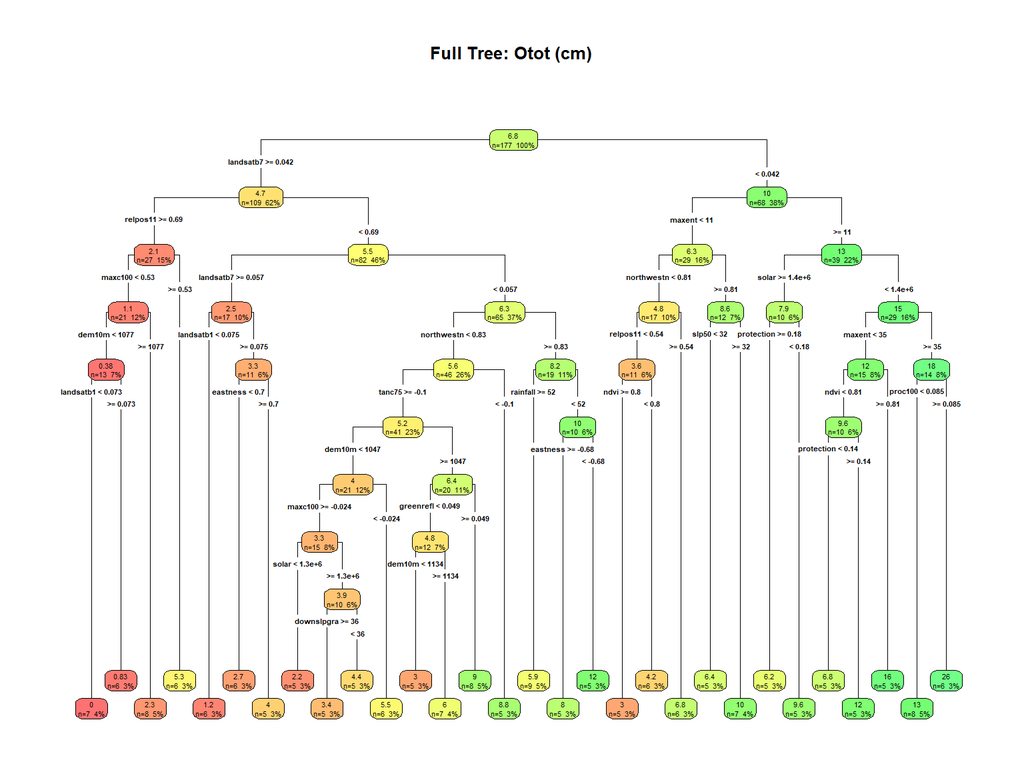

```r
rpart.plot(tree_full,
           type = 4, extra = 101, box.palette = "RdYlGn",
           main = "Full Tree: Otot (cm)")
```

> **How to read this tree:**  
> - **Top of node:** Split condition. Samples satisfying the rule go left; others right.  
> - **Middle:** Predicted O horizon thickness (mean of training samples at this node).  
> - **Bottom:** Percentage of training samples at this node.

## 4.3 Pruning with Cost-Complexity

Allowing a tree to grow until every leaf contains a single sample produces **zero training error but extreme overfitting** — the model has memorized noise rather than learning relationships.

**Cost-complexity pruning** penalizes tree size by a complexity parameter $\alpha$ (`cp` in R):

$$R_\alpha(T) = R(T) + \alpha \times
|T|$$

where $R(T)$ is training error and $|T|$ is the number of leaf nodes. As $\alpha$ increases, the optimal tree shrinks. Cross-validation selects the best $\alpha$.

```r
# Examine the complexity parameter table
printcp(tree_full)
```

```
#>
#> Regression tree:
#> rpart(formula = as.formula(paste("Otot ~", paste(xvars_terrain,
#>     collapse = " + "))), data = cal, method = "anova", control = rpart.control(cp = 0,
#>     minsplit = 10, minbucket = 5))
#>
#> Variables actually used in tree construction:
#>  [1] dem10m     downslpgra eastness   greenrefl  landsatb1  landsatb7
#>  [7] maxc100    maxent     ndvi       northwestn proc100    protection
#> [13] rainfall   relpos11   slp50      solar      tanc75
#>
#> Root node error: 6714.3/177 = 37.934
#>
#> n= 177
#>
#>            CP nsplit rel error  xerror    xstd
#> 1  0.19389181      0   1.00000 1.00791 0.20480
#> 2  0.11484792      1   0.80611 0.82475 0.16771
#> 3  0.06585515      2   0.69126 0.86712 0.15288
#> 4  0.03665785      5   0.49369 0.94553 0.17479
#> 5  0.02888463      6   0.45704 0.95262 0.15894
#> 6  0.01908370      7   0.42815 0.97091 0.14525
#> 7  0.01527732      8   0.40907 0.99945 0.14588
#> 8  0.01346156      9   0.39379 1.04702 0.14927
#> 9  0.01311196     10   0.38033 1.04792 0.14923
#> 10 0.01234398     11   0.36722 1.03452 0.14927
#> 11 0.01167660     12   0.35487 1.03964 0.14968
#> 12 0.01039088     13   0.34320 1.03964 0.14968
#> 13 0.00720851     16   0.31202 1.02666 0.14610
#> 14 0.00608546     17   0.30482 1.05531 0.14835
#> 15 0.00590980     18   0.29873 1.05386 0.14860
#> 16 0.00430426     19   0.29282 1.04999 0.14862
#> 17 0.00390958     20   0.28852 1.05469 0.14875
#> 18 0.00299646     21   0.28461 1.05965 0.14881
#> 19 0.00274143     22   0.28161 1.06336 0.14876
#> 20 0.00256470     23   0.27887 1.06287 0.14877
#> 21 0.00143475     24   0.27630 1.06024 0.14889
#> 22 0.00072212     25   0.27487 1.04828 0.14652
#> 23 0.00055287     26   0.27415 1.04964 0.14655
#> 24 0.00037234     27   0.27359 1.05016 0.14656
#> 25 0.00033415     28   0.27322 1.04992 0.14657
#> 26 0.00000000     29   0.27289 1.05089 0.14656
```

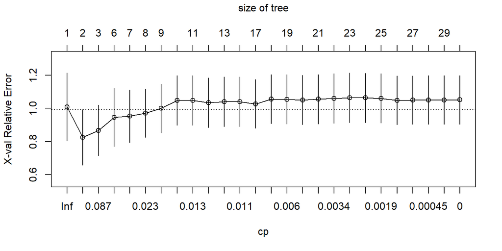

```r
# Plot CV error vs tree size
plotcp(tree_full)
```

The **1-SE rule** selects the *smallest* tree whose CV error is within one standard error of the minimum — preferring interpretability over minimal CV error:

```r
# Extract CP table components
cp_tbl  <- tree_full$cptable
xerr    <- cp_tbl[, "xerror"]
xstd    <- cp_tbl[, "xstd"]

# Minimum CV error and its location
min_idx <- which.min(xerr)
thresh  <- xerr[min_idx] + xstd[min_idx]

# 1-SE rule: largest CP (simplest tree) still within 1 SE of the minimum
cp_1se  <- cp_tbl[min(which(xerr <= thresh)), "CP"]
cat(sprintf("Minimum-error CP: %.5f\n", cp_tbl[min_idx, "CP"]))
```

```
#> Minimum-error CP: 0.11485
```

```r
cat(sprintf("1-SE rule CP:     %.5f\n", cp_1se))
```

```
#> 1-SE rule CP:     0.11485
```

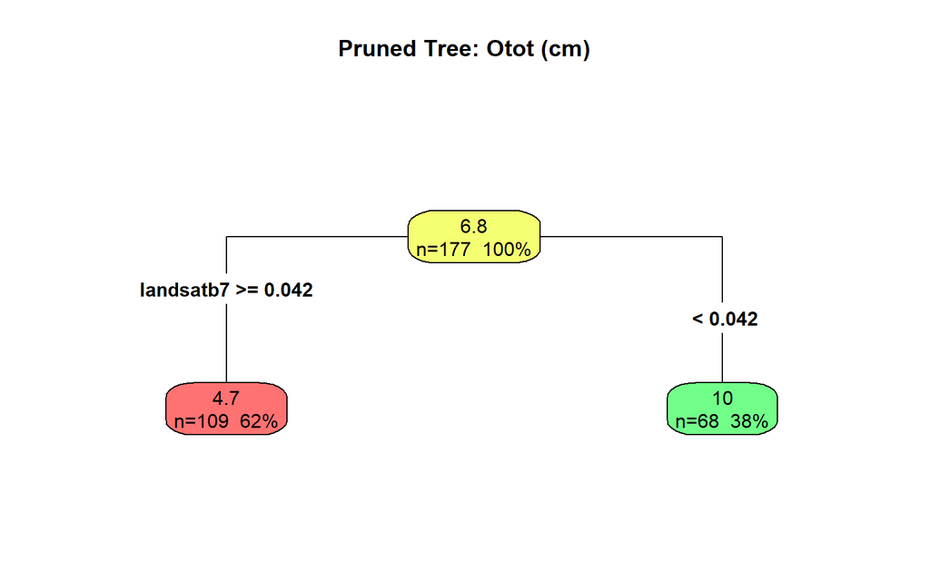

```r
tree_pruned <- prune(tree_full, cp = cp_1se)

rpart.plot(tree_pruned,
           type = 4, extra = 101, box.palette = "RdYlGn",
           main = "Pruned Tree: Otot (cm)")
```

## 4.4 Model Accuracy Comparison

```r
# Predict on validation set
pred_full   <- predict(tree_full,   newdata = val)
pred_pruned <- predict(tree_pruned, newdata = val)

# RMSE on original Otot scale
rmse_full   <- RMSE(pred = pred_full,   obs = val$Otot)
rmse_pruned <- RMSE(pred = pred_pruned, obs = val$Otot)

rpart_results <- data.frame(
  Model  = c("rpart full", "rpart pruned (1-SE)"),
  RMSE   = round(c(rmse_full, rmse_pruned), 3),
  Leaves = c(sum(tree_full$frame$var == "<leaf>"),
             sum(tree_pruned$frame$var == "<leaf>"))
)
print(rpart_results)
```

```
#>                 Model  RMSE Leaves
#> 1          rpart full 5.979     30
#> 2 rpart pruned (1-SE) 4.907      2
```

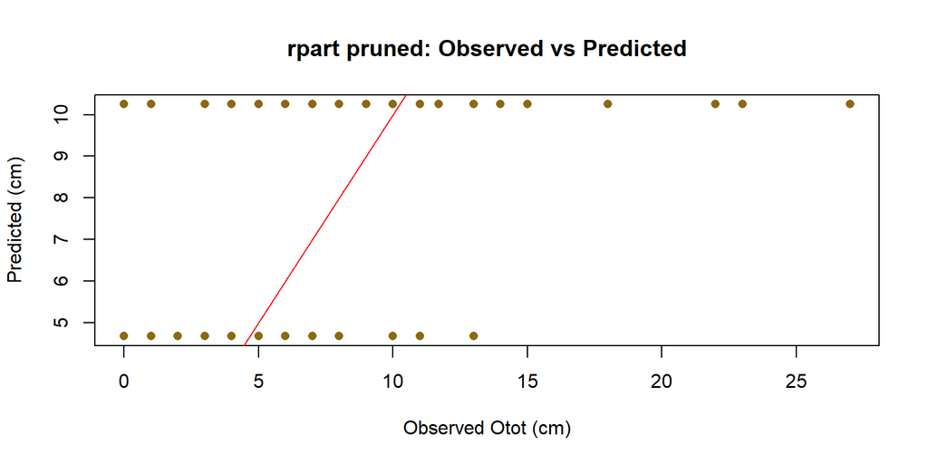

```r
plot(val$Otot, pred_pruned,
     xlab = "Observed Otot (cm)", ylab = "Predicted (cm)",
     main = "rpart pruned: Observed vs Predicted", col = "#8b6914", pch = 16)
abline(0, 1, col = "red")
```

> **Key insight:** The pruned tree avoids fitting noise despite having far fewer nodes (bias-variance tradeoff).

> **Questions:**  
> 1. What was the root split variable? Does it make pedological sense for O horizon thickness?  
> 2. How much did pruning reduce the number of leaves compared to the full tree?  
> 3. Does the pruned tree RMSE indicate a useful model for field applications?

# 5 Part 4 — Random Forest: O Horizon Thickness

## 5.1 Theory: Why Ensembles Work

A single decision tree has **high variance** — small changes in training data produce very different trees. The core idea of **bagging** (Breiman, 1996) is that averaging many high-variance models cancels out their individual noise:

$$\hat{f}_{\text{bag}}(x) = \frac{1}{B}
\sum_{b=1}^{B} T_b(x)$$

For $B$ trees each with variance $\sigma^2$ and pairwise correlation $\rho$:

$$\text{Var}\!\left(\hat{f}_{\text{RF}}\right) =
\rho\sigma^2 + \frac{(1-\rho)\,\sigma^2}{B}$$

**Random Forest’s key innovation** (Breiman, 2001): at each split, only a random subset of `mtry` features is considered. This **decorrelates** the trees, reducing $\rho$ and shrinking the irreducible first term. As $B \to \infty$, $\text{Var} \to \rho\sigma^2$.

## 5.2 Build RF: O Horizon Thickness

```r
# Fresh load — ensure clean state
soildata <- read.csv("soildata.csv", header = TRUE, sep = ",")
soildata$spodint  <- ordered(as.factor(soildata$spodint))
soildata$tipmound <- ordered(as.factor(soildata$tipmound))

set.seed(42)
rf_otot <- randomForest(
  Otot ~ rainfall + geology + aachn + dem10m + downslpgra + eastness + greenrefl +
    landsatb1 + landsatb2 + landsatb3 + landsatb7 + maxc100 + maxent + minc100 +
    mirref + ndvi + northeastn + northness + northwestn + planc100 + proc100 +
    protection + relpos11 + slp50 + solar + tanc75,
  data       = soildata,
  importance = TRUE,
  ntree      = 1000,
  mtry       = 10
)

# Statistical summary — % variance explained and MSE
print(rf_otot)
```

```
#>
#> Call:
#>  randomForest(formula = Otot ~ rainfall + geology + aachn + dem10m +      downslpgra + eastness + greenrefl + landsatb1 + landsatb2 +      landsatb3 + landsatb7 + maxc100 + maxent + minc100 + mirref +      ndvi + northeastn + northness + northwestn + planc100 + proc100 +      protection + relpos1…
#>                Type of random forest: regression
#>                      Number of trees: 1000
#> No. of variables tried at each split: 10
#>
#>           Mean of squared residuals: 28.23056
#>                     % Var explained: 21.49
```

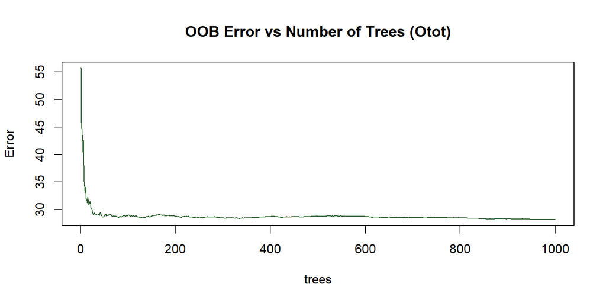

```r
# OOB error vs number of trees — use this to tune ntree
plot(rf_otot,
     main = "OOB Error vs Number of Trees (Otot)",
     col  = "#2c5f2e")
```

```r
library(caret)
library(ranger)

# ── Covariates ───────────────────────────────────────────────────────────────
predictors <- c(
  "rainfall",   "geology",    "aachn",      "dem10m",     "downslpgra",
  "eastness",   "greenrefl",  "landsatb1",  "landsatb2",  "landsatb3",
  "landsatb7",  "maxc100",    "maxent",     "minc100",    "mirref",
  "ndvi",       "northeastn", "northness",  "northwestn", "planc100",
  "proc100",    "protection", "relpos11",   "slp50",      "solar",
  "tanc75"
)

# ── Tuning grid ──────────────────────────────────────────────────────────────
tuning_grid <- expand.grid(
  mtry          = c(5, 8, 10, 13),
  splitrule     = c("variance", "extratrees"),
  min.node.size = c(3, 5, 10, 15, 20)
)

# ── Cross-validation control ─────────────────────────────────────────────────
ctrl <- trainControl(
  method          = "cv",
  number          = 10,
  savePredictions = "final"
)

# ── Train ────────────────────────────────────────────────────────────────────
rf_tuned <- train(
  x         = soildata[, predictors],
  y         = soildata$Otot,
  method    = "ranger",
  trControl = ctrl,
  tuneGrid  = tuning_grid,
  num.trees = 500,
  metric    = "RMSE"
)

# ── Results ──────────────────────────────────────────────────────────────────
rf_tuned$bestTune
```

|  | mtry | splitrule | min.node.size |
| --- | --- | --- | --- |
| 17 | 8 | extratrees | 5 |

```r
rf_tuned$results
```

|  | mtry | splitrule | min.node.size | RMSE | Rsquared | MAE | RMSESD | RsquaredSD | MAESD |
| --- | --- | --- | --- | --- | --- | --- | --- | --- | --- |
| 1 | 5 | variance | 3 | 5.192344 | 0.2851627 | 3.881837 | 1.174684 | 0.1838720 | 0.7007865 |
| 2 | 5 | variance | 5 | 5.198711 | 0.2768230 | 3.898143 | 1.173234 | 0.1710669 | 0.7047905 |
| 3 | 5 | variance | 10 | 5.207091 | 0.2745708 | 3.907123 | 1.148066 | 0.1634737 | 0.6627888 |
| 4 | 5 | variance | 15 | 5.219556 | 0.2652839 | 3.914866 | 1.146257 | 0.1505329 | 0.6528335 |
| 5 | 5 | variance | 20 | 5.247853 | 0.2627745 | 3.936372 | 1.145343 | 0.1594131 | 0.6619536 |
| 6 | 5 | extratrees | 3 | 5.059003 | 0.3338076 | 3.812739 | 1.133032 | 0.1823035 | 0.6484307 |
| 7 | 5 | extratrees | 5 | 5.047152 | 0.3436005 | 3.800354 | 1.113954 | 0.1831899 | 0.6306157 |
| 8 | 5 | extratrees | 10 | 5.110471 | 0.3268165 | 3.855774 | 1.150421 | 0.1812698 | 0.6602153 |
| 9 | 5 | extratrees | 15 | 5.130452 | 0.3281189 | 3.859724 | 1.158867 | 0.1791898 | 0.6468692 |
| 10 | 5 | extratrees | 20 | 5.163595 | 0.3202082 | 3.883219 | 1.160102 | 0.1824802 | 0.6280702 |

[output cut: 30 more lines]

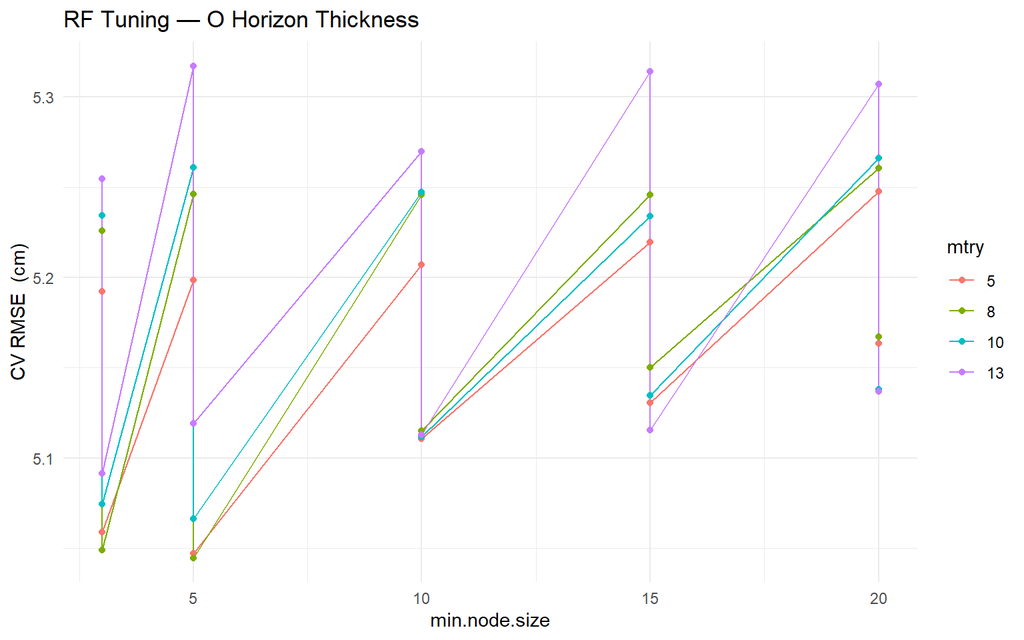

```r
# RMSE surface plot
ggplot(rf_tuned$results,
       aes(x      = min.node.size,
           y      = RMSE,
           colour = factor(mtry),
           group  = factor(mtry))) +
  geom_line() +
  geom_point() +
  labs(title  = "RF Tuning — O Horizon Thickness",
       x      = "min.node.size",
       y      = "CV RMSE  (cm)",
       colour = "mtry") +
  theme_minimal()
```

```r
# ── Refit final model with best parameters ────────────────────────────────────
rf_final <- ranger(
  formula       = Otot ~ .,
  data          = soildata[, c(predictors, "Otot")],
  num.trees     = 500,
  mtry          = rf_tuned$bestTune$mtry,
  min.node.size = rf_tuned$bestTune$min.node.size,
  importance    = "permutation"
)

# ── Diagnostics ───────────────────────────────────────────────────────────────
sqrt(rf_final$prediction.error)          # OOB RMSE
```

```
#> [1] 5.286536
```

```r
sort(importance(rf_final), decreasing = TRUE)   # variable importance ranked
```

```
#>   landsatb7      maxent  northwestn  protection       solar  northeastn
#>  5.90140804  4.94728672  2.83230425  1.76209728  1.75695274  1.42687241
#>      dem10m  downslpgra   northness    rainfall    relpos11      mirref
#>  1.00503164  0.80915692  0.79491794  0.78509495  0.78038791  0.72789722
#>       slp50       aachn     maxc100    planc100    eastness      tanc75
#>  0.71299641  0.55455587  0.54572276  0.54147697  0.41849414  0.37265265
#>     proc100   landsatb3     minc100     geology        ndvi   greenrefl
#>  0.31689993  0.26168455  0.24575880  0.13898189  0.10680202  0.09325397
#>   landsatb1   landsatb2
#>  0.02736148 -0.01630097
```

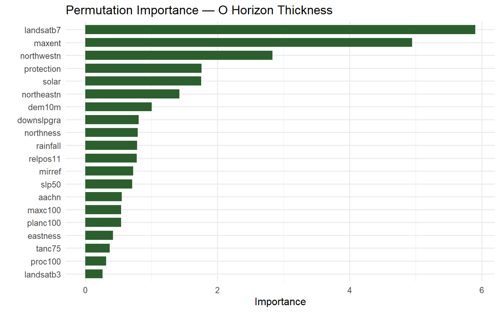

```r
# ── Plot Variable Importance ───────────────────────────────────────────────────────────────
library(vip)
# Bar chart — works directly with ranger objects
vip(rf_final, num_features = 20,
    aesthetics = list(fill = "#2c5f2e", width = 0.7)) +
  theme_minimal(base_size = 12) +
  labs(title = "Permutation Importance — O Horizon Thickness")
```

## 5.3 Effect of Outlier Removal

The `Otot` distribution has a strongly influential outlier — the single Histosol observation with very thick O horizons. Let’s examine its effect:

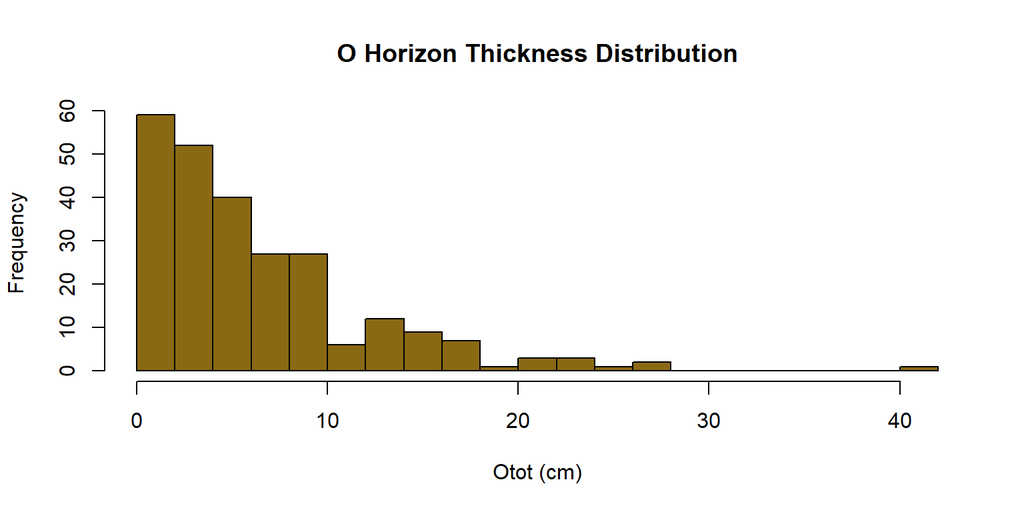

```r
hist(soildata$Otot, breaks = 20,
     main = "O Horizon Thickness Distribution",
     xlab = "Otot (cm)", col = "#8b6914")
```

```r
# Remove the Histosol observation
soildata_nohist <- droplevels(subset(soildata, order != "histosol"))
cat(sprintf("Observations removed: %d\n",
            nrow(soildata) - nrow(soildata_nohist)))
```

```
#> Observations removed: 1
```

```r
set.seed(42)
rf_otot2 <- randomForest(
  Otot ~ rainfall + geology + aachn + dem10m + downslpgra + eastness + greenrefl +
    landsatb1 + landsatb2 + landsatb3 + landsatb7 + maxc100 + maxent + minc100 +
    mirref + ndvi + northeastn + northness + northwestn + planc100 + proc100 +
    protection + relpos11 + slp50 + solar + tanc75,
  data       = soildata_nohist,
  importance = TRUE,
  ntree      = 1000,
  mtry       = 9
)

# Compare both models side by side
cat("--- With Histosol ---\n")
```

```
#> --- With Histosol ---
```

```r
cat(sprintf("  %% Var explained: %.1f%%\n", rf_otot$rsq[1000] * 100))
```

```
#>   % Var explained: 21.5%
```

```r
cat(sprintf("  MSE (OOB):       %.3f\n",    rf_otot$mse[1000]))
```

```
#>   MSE (OOB):       28.231
```

```r
cat(sprintf("  RMSE (OOB):      %.3f cm\n", sqrt(rf_otot$mse[1000])))
```

```
#>   RMSE (OOB):      5.313 cm
```

```r
cat("\n--- Without Histosol ---\n")
```

```
#>
#> --- Without Histosol ---
```

```r
cat(sprintf("  %% Var explained: %.1f%%\n", rf_otot2$rsq[1000] * 100))
```

```
#>   % Var explained: 23.3%
```

```r
cat(sprintf("  MSE (OOB):       %.3f\n",    rf_otot2$mse[1000]))
```

```
#>   MSE (OOB):       24.067
```

```r
cat(sprintf("  RMSE (OOB):      %.3f cm\n", sqrt(rf_otot2$mse[1000])))
```

```
#>   RMSE (OOB):      4.906 cm
```

```r
# ── Train ────────────────────────────────────────────────────────────────────
rf_tuned <- train(
  x         = soildata_nohist[, predictors],
  y         = soildata_nohist$Otot,
  method    = "ranger",
  trControl = ctrl,
  tuneGrid  = tuning_grid,
  num.trees = 500,
  metric    = "RMSE"
)

# ── Results ──────────────────────────────────────────────────────────────────
rf_tuned$bestTune
```

|  | mtry | splitrule | min.node.size |
| --- | --- | --- | --- |
| 16 | 8 | extratrees | 3 |

```r
rf_tuned$results
```

|  | mtry | splitrule | min.node.size | RMSE | Rsquared | MAE | RMSESD | RsquaredSD | MAESD |
| --- | --- | --- | --- | --- | --- | --- | --- | --- | --- |
| 1 | 5 | variance | 3 | 4.844775 | 0.2582588 | 3.716334 | 0.7324852 | 0.1888704 | 0.4174741 |
| 2 | 5 | variance | 5 | 4.865366 | 0.2504246 | 3.755055 | 0.7295924 | 0.1825527 | 0.4289905 |
| 3 | 5 | variance | 10 | 4.892628 | 0.2458519 | 3.752963 | 0.7255406 | 0.1808351 | 0.4344867 |
| 4 | 5 | variance | 15 | 4.880618 | 0.2454454 | 3.744018 | 0.7153246 | 0.1769083 | 0.4492029 |
| 5 | 5 | variance | 20 | 4.868216 | 0.2522267 | 3.739953 | 0.6931701 | 0.1777823 | 0.4263435 |
| 6 | 5 | extratrees | 3 | 4.794343 | 0.2792821 | 3.684881 | 0.6855768 | 0.1772666 | 0.4254827 |
| 7 | 5 | extratrees | 5 | 4.778382 | 0.2876607 | 3.684368 | 0.6474253 | 0.1860493 | 0.4181123 |
| 8 | 5 | extratrees | 10 | 4.804936 | 0.2821427 | 3.687650 | 0.6603775 | 0.1846941 | 0.3989791 |
| 9 | 5 | extratrees | 15 | 4.853999 | 0.2737961 | 3.716862 | 0.5900593 | 0.1755390 | 0.3736857 |
| 10 | 5 | extratrees | 20 | 4.861924 | 0.2773612 | 3.731399 | 0.5956549 | 0.1703950 | 0.3799841 |

[output cut: 30 more lines]

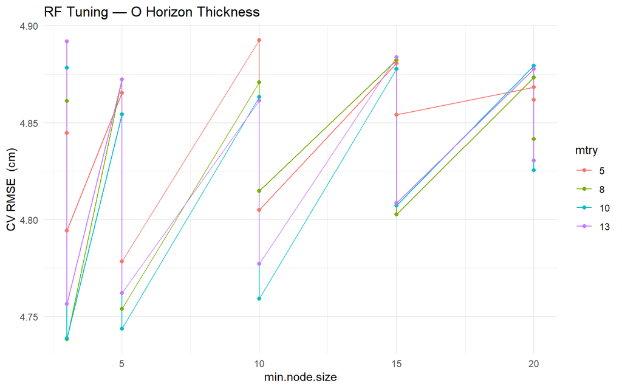

```r
# RMSE surface plot
ggplot(rf_tuned$results,
       aes(x      = min.node.size,
           y      = RMSE,
           colour = factor(mtry),
           group  = factor(mtry))) +
  geom_line() +
  geom_point() +
  labs(title  = "RF Tuning — O Horizon Thickness",
       x      = "min.node.size",
       y      = "CV RMSE  (cm)",
       colour = "mtry") +
  theme_minimal()
```

```r
# ── Refit final model with best parameters ────────────────────────────────────
rf_final <- ranger(
  formula       = Otot ~ .,
  data          = soildata_nohist[, c(predictors, "Otot")],
  num.trees     = 500,
  mtry          = rf_tuned$bestTune$mtry,
  min.node.size = rf_tuned$bestTune$min.node.size,
  importance    = "permutation"
)

# ── Diagnostics ───────────────────────────────────────────────────────────────
sqrt(rf_final$prediction.error)          # OOB RMSE
```

```
#> [1] 4.932373
```

```r
sort(importance(rf_final), decreasing = TRUE)   # variable importance ranked
```

```
#>  landsatb7     maxent northwestn      solar protection   rainfall  northness
#> 5.56470606 3.34918283 1.90889500 1.45556857 1.31027549 0.72632890 0.62615455
#>      aachn    maxc100      slp50 northeastn    minc100   eastness    proc100
#> 0.56675921 0.52885034 0.52493063 0.50504582 0.48645082 0.47786431 0.46508244
#>     dem10m   relpos11  landsatb3 downslpgra   planc100     mirref  greenrefl
#> 0.45402584 0.43796553 0.38430809 0.36033679 0.30806039 0.26968451 0.22724734
#>     tanc75       ndvi    geology  landsatb1  landsatb2
#> 0.21854461 0.18318276 0.16649800 0.07438199 0.06176013
```

## 5.4 Model Comparison: rpart vs RF

To compare rpart and Random Forest fairly, **both models must be trained on the same data and evaluated on the same held-out set**.

| Evaluation method | What it measures | Notes |
| --- | --- | --- |
| **Split-sample** (val set) | Error on truly unseen data from a fixed 30% holdout | Directly comparable across model types |
| **OOB** | Bootstrap leave-one-out estimate from the full training set | RF-specific; model saw all data; not comparable to val-set RMSE |

Both models are trained on `cal_nohist` (70%, Histosol removed) and evaluated on `val`. Removing the Histosol from *both* training sets ensures neither model’s performance is driven by a single extreme outlier. `rf_final` (full-data) is preserved for downstream DSM use.

> **Note on the 1-SE rule and outliers:** The Histosol is the dominant source of variance in `Otot`. Removing it from `cal` can cause the 1-SE rule to choose a stump (no splits) because even the smallest tree is within one standard error of the minimum CV error — the signal is too weak to justify any split with confidence. When this happens the code falls back to the minimum-error CP, which keeps the splits the data *can* support. This is itself a teaching point: the 1-SE rule is conservative, and outliers can inflate apparent signal.

```r
# ── Shared training set: cal minus Histosol ───────────────────────────────────
cal_nohist <- droplevels(subset(cal, order != "histosol"))

# ── Rebuild rpart on cal_nohist — same formula and 1-SE rule ─────────────────
tree_full_nh <- rpart(
  formula = as.formula(paste("Otot ~", paste(xvars_terrain, collapse = " + "))),
  data    = cal_nohist,
  method  = "anova",
  control = rpart.control(cp = 0, minsplit = 10, minbucket = 5)
)
cp_tbl_nh <- tree_full_nh$cptable
xerr_nh   <- cp_tbl_nh[, "xerror"]
xstd_nh   <- cp_tbl_nh[, "xstd"]
min_nh    <- which.min(xerr_nh)
thresh_nh <- xerr_nh[min_nh] + xstd_nh[min_nh]

# 1-SE CP — use min-error CP as fallback if 1-SE collapses to a stump
cp_1se_nh <- cp_tbl_nh[min(which(xerr_nh <= thresh_nh)), "CP"]
tree_pruned_nh <- prune(tree_full_nh, cp = cp_1se_nh)
n_leaves_nh    <- sum(tree_pruned_nh$frame$var == "<leaf>")

if (n_leaves_nh == 1) {
  # 1-SE collapsed to stump — removing the Histosol eliminated the dominant
  # variance source; fall back to the minimum-error CP to keep usable splits
  message("1-SE rule produced a stump on cal_nohist; falling back to min-error CP.")
  cp_1se_nh      <- cp_tbl_nh[min_nh, "CP"]
  tree_pruned_nh <- prune(tree_full_nh, cp = cp_1se_nh)
  n_leaves_nh    <- sum(tree_pruned_nh$frame$var == "<leaf>")
  rpart_label    <- "rpart pruned (min-error CP, fallback) [*]"
} else {
  rpart_label    <- "rpart pruned (1-SE CP) [*]"
}

pred_rpart_nh <- predict(tree_pruned_nh, newdata = val)
rmse_rpart_nh <- RMSE(pred = pred_rpart_nh, obs = val$Otot)
r2_rpart_nh   <- cor(pred_rpart_nh, val$Otot)^2

cat(sprintf("rpart (cal_nohist) — leaves: %d  CP used: %.5f\n",
            n_leaves_nh, cp_1se_nh))
```

```
#> rpart (cal_nohist) — leaves: 3  CP used: 0.06485
```

```r
# ── RF on cal_nohist — best hyperparameters from earlier tuning ───────────────
set.seed(42)
rf_val_compare <- ranger(
  formula       = Otot ~ .,
  data          = cal_nohist[, c(predictors, "Otot")],
  num.trees     = 500,
  mtry          = rf_tuned$bestTune$mtry,
  min.node.size = rf_tuned$bestTune$min.node.size,
  importance    = "none"
)

pred_rf_val <- predict(rf_val_compare, data = val)$predictions
rmse_rf_val <- RMSE(pred = pred_rf_val, obs = val$Otot)
r2_rf_val   <- cor(pred_rf_val, val$Otot)^2

# ── OOB metrics from full-data RF — for reference only ───────────────────────
rmse_rf_oob <- sqrt(rf_otot2$mse[1000])
r2_rf_oob   <- rf_otot2$rsq[1000]

# ── Comparison table ──────────────────────────────────────────────────────────
comparison <- data.frame(
  Model        = c(
    rpart_label,
    "Random Forest - val set [*]",
    "Random Forest - OOB [ref]"
  ),
  Trained_on   = c(
    "cal_nohist 70%",
    "cal_nohist 70%",
    "all data (no Histosol)"
  ),
  Evaluated_on = c(
    "val 30%",
    "val 30%",
    "OOB bootstrap"
  ),
  RMSE_cm = round(c(rmse_rpart_nh, rmse_rf_val, rmse_rf_oob), 3),
  R2      = round(c(r2_rpart_nh,   r2_rf_val,   r2_rf_oob),   3)
)
print(comparison)
```

```
#>                                       Model             Trained_on
#> 1 rpart pruned (min-error CP, fallback) [*]         cal_nohist 70%
#> 2               Random Forest - val set [*]         cal_nohist 70%
#> 3                 Random Forest - OOB [ref] all data (no Histosol)
#>    Evaluated_on RMSE_cm    R2
#> 1       val 30%   4.843 0.260
#> 2       val 30%   5.102 0.213
#> 3 OOB bootstrap   4.906 0.233
```

```r
cat("\n[*]  Direct head-to-head: identical training data (cal_nohist), identical val set.\n")
```

```
#>
#> [*]  Direct head-to-head: identical training data (cal_nohist), identical val set.
```

```r
cat("[ref] OOB reference only: RF trained on full data, not comparable to val-set rows.\n")
```

```
#> [ref] OOB reference only: RF trained on full data, not comparable to val-set rows.
```

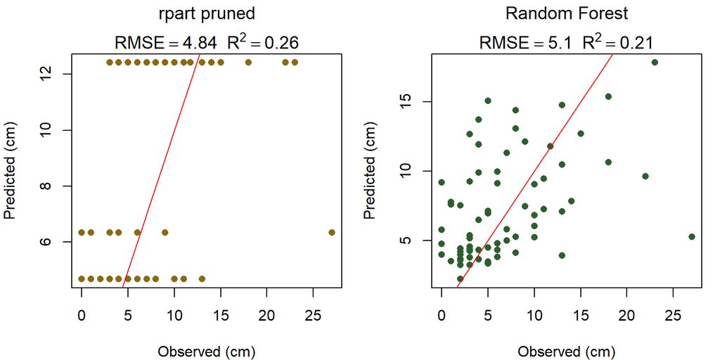

```r
# Observed vs predicted on the same val set — matched training data
par(mfrow = c(1, 2), mar = c(4, 4, 3, 1))  # tighten top margin

plot(val$Otot, pred_rpart_nh,
     xlab = "Observed (cm)", ylab = "Predicted (cm)",
     col = "#8b6914", pch = 16)
title(main = bquote(atop("rpart pruned",
                         RMSE == .(round(rmse_rpart_nh, 2)) ~~ R^2 == .(round(r2_rpart_nh, 2)))))
abline(0, 1, col = "red")

plot(val$Otot, pred_rf_val,
     xlab = "Observed (cm)", ylab = "Predicted (cm)",
     col = "#2c5f2e", pch = 16)
title(main = bquote(atop("Random Forest",
                         RMSE == .(round(rmse_rf_val, 2)) ~~ R^2 == .(round(r2_rf_val, 2)))))
abline(0, 1, col = "red")
```

```r
par(mfrow = c(1, 1))
```

> **Interpretation:**  
> Rows 1 and 2 are a true head-to-head comparison — identical training set (`cal_nohist`), identical evaluation set (`val`). Any difference in RMSE and R² is due solely to the algorithm, not data leakage or sample composition. The OOB row uses the full dataset for training; it cannot be fairly compared to the val-set rows even though OOB is theoretically unbiased on its own training set.

## 5.5 Variable Importance

For regression RF, two importance metrics are reported:  
- **%IncMSE**: average increase in OOB MSE when the variable is permuted. Larger = more important.  
- **IncNodePurity**: total reduction in RSS across all splits on this variable, summed across all trees. Faster to compute but biased toward continuous/high-cardinality variables.

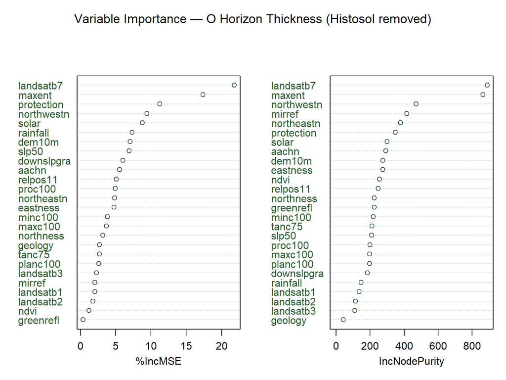

```r
varImpPlot(rf_otot2,
           main = "Variable Importance — O Horizon Thickness (Histosol removed)",
           col  = "#2c5f2e")
```

```r
# Sorted tabular importance — useful for reporting
randomForest::importance(rf_otot2) |>
  as.data.frame() |>
  arrange(desc(`%IncMSE`))
```

|  | %IncMSE | IncNodePurity |
| --- | --- | --- |
| landsatb7 | 21.7828777 | 888.49399 |
| maxent | 17.3697111 | 863.91838 |
| protection | 11.2504300 | 348.05196 |
| northwestn | 9.4064310 | 469.47225 |
| solar | 8.7506545 | 300.77519 |
| rainfall | 7.3410573 | 147.21850 |
| dem10m | 7.0435198 | 274.61871 |
| slp50 | 6.8972044 | 209.63659 |
| downslpgra | 6.0216729 | 184.49910 |
| aachn | 5.5550790 | 291.17253 |

[output cut: 16 more lines]

> **Questions:**  
> 1. Did removing the Histosol outlier improve % variance explained?  
> 2. What is the OOB error (MSE and % variance explained)? How does this compare with the rpart regression tree from Part 2?  
> 3. Which variable had the highest %IncMSE? What soil-forming factor does this represent?  
> 4. Do %IncMSE and IncNodePurity agree on the ranking of top predictors? If not, why might they differ?

## 5.6 Exercise: Folistic Epipedon Prediction

Using the `soildata` dataset, build a Random Forest **classification** model to predict the probability of a **folistic epipedon**. Folistic epipedons provide habitat for the Northern Flying Squirrel and are a key mapping target in the Monongahela National Forest.

```r
# Recode epipedon: combine ochric and umbric into nonfolistic
soildata$epipedon2 <- ifelse(
  soildata$epipedon %in% c("ochric", "umbric"),
  "nonfolistic",
  soildata$epipedon
)
table(soildata$epipedon2)
```

```
#>
#>    folistic nonfolistic
#>          27         223
```

```r
# YOUR CODE HERE
# Build a randomForest classification model predicting epipedon2
# Tune ntree and mtry to capture the most variability
# Hint: use importance=TRUE and examine varImpPlot()

# rf_epipedon <- randomForest(
#   as.factor(epipedon2) ~ ...,
#   data = soildata,
#   ntree = ???,
#   mtry  = ???,
#   importance = TRUE
# )
```

> **Self-check questions:**  
> 1. What is the OOB error rate?  
> 2. Compare this classification model with the `Otot` regression model. Which would be better for spatial interpolation of folistic epipedon risk?  
> 3. Which covariates are most important for predicting folistic epipedons? Do they differ from the Otot model? What soil-forming factor explanation would you give?

# 6 Part 5 — Feature Selection with Boruta

## 6.1 Theory: Why Feature Selection Matters

With many environmental covariates available (terrain + spectral + climate), some predictors are noise. Including irrelevant features:

- Increases computation time
- Can reduce model accuracy via the “curse of dimensionality”
- Complicates interpretation

**Boruta** is a wrapper around Random Forest that identifies relevant features by comparing each predictor’s importance against the importance of shuffled “shadow” copies of itself. Features that consistently outperform their shadow are confirmed as important.

## 6.2 Run Boruta

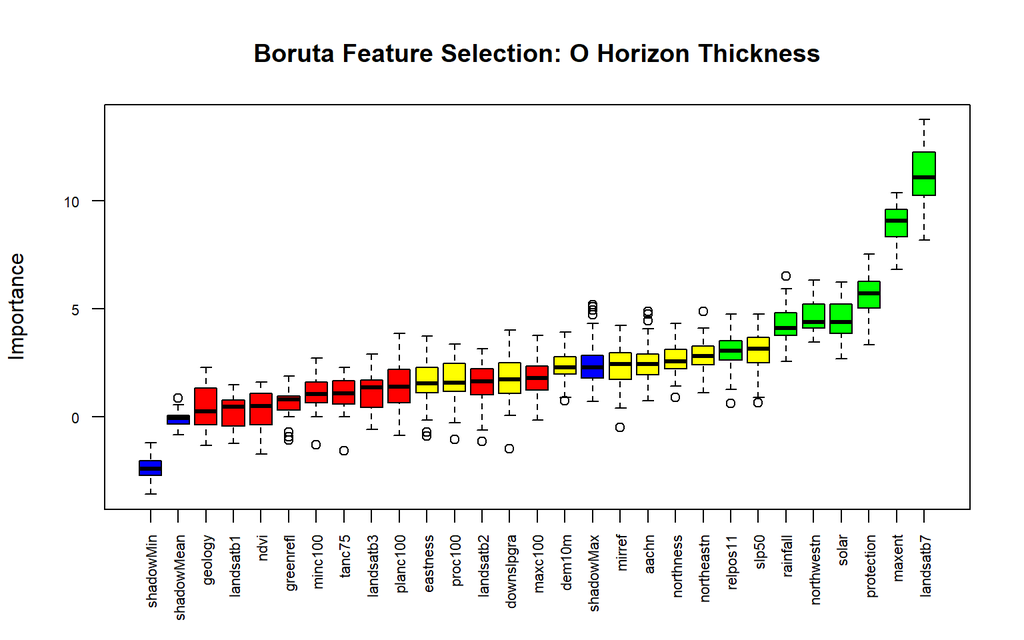

```r
# Fresh load for O horizon thickness prediction
soildata <- read.csv("soildata.csv", header = TRUE, sep = ",")
yvar  <- "Otot"
xvars_bor <- c(
  "rainfall", "geology", "aachn", "dem10m", "downslpgra", "eastness",
  "greenrefl", "landsatb1", "landsatb2", "landsatb3", "landsatb7",
  "maxc100", "maxent", "minc100", "mirref", "ndvi",
  "northeastn", "northness", "northwestn", "planc100", "proc100",
  "protection", "relpos11", "slp50", "solar", "tanc75"
)

set.seed(42)
fs_bor <- Boruta(
  y       = soildata[[yvar]],
  x       = soildata[, xvars_bor],
  maxRuns = 50,
  doTrace = 1
)

# Variable importance plot (green = confirmed, yellow = tentative, red = rejected)
plot(fs_bor,
     xlab = "", las = 2, cex.axis = 0.7,
     main = "Boruta Feature Selection: O Horizon Thickness")
```

```r
# Confirmed important features
vars_confirmed <- getSelectedAttributes(fs_bor)
cat("Confirmed important features:\n")
```

```
#> Confirmed important features:
```

```r
print(vars_confirmed)
```

```
#> [1] "rainfall"   "landsatb7"  "maxent"     "northwestn" "protection"
#> [6] "relpos11"   "solar"
```

```r
cat(sprintf("\n%d of %d features confirmed important.\n",
            length(vars_confirmed), length(xvars_bor)))
```

```
#>
#> 7 of 26 features confirmed important.
```

```r
# Detailed attribute statistics
attrib_stats <- attStats(fs_bor)
attrib_stats[order(-attrib_stats$meanImp), c("meanImp", "decision")]
```

|  | meanImp | decision |
| --- | --- | --- |
| landsatb7 | 11.1384275 | Confirmed |
| maxent | 8.9827519 | Confirmed |
| protection | 5.5971945 | Confirmed |
| northwestn | 4.6376693 | Confirmed |
| solar | 4.5598708 | Confirmed |
| rainfall | 4.2859381 | Confirmed |
| relpos11 | 3.0621119 | Confirmed |
| slp50 | 2.9593261 | Tentative |
| northeastn | 2.8677480 | Tentative |
| northness | 2.6436249 | Tentative |

[output cut: 16 more lines]

# 7 Part 6 — Cross-Validation with caret and ranger

## 7.1 Theory: Why Cross-Validate?

The primary purpose of CV here is **hyperparameter tuning**: `caret` fits ranger repeatedly across a grid of `mtry`, `min.node.size`, and `splitrule` values, selecting the combination with the best average held-out RMSE across 10 folds. CV also generalizes to any model type, making RF directly comparable to rpart or other algorithms on the same folds.

## 7.2 10-Fold CV Without Feature Selection

```r
tc <- trainControl(
  method       = "cv",
  number       = 10,
  returnResamp = "all",
  savePredictions = TRUE,
  verboseIter  = FALSE
)

set.seed(42)
dep_tr_full <- train(
  y          = soildata[[yvar]],
  x          = soildata[, xvars_bor],
  method     = "ranger",
  importance = "permutation",
  trControl  = tc
)

print(dep_tr_full)
```

[output not shown]

## 7.3 10-Fold CV With Boruta Features

```r
set.seed(42)
dep_tr_bor <- train(
  y          = soildata[[yvar]],
  x          = soildata[, vars_confirmed],
  method     = "ranger",
  importance = "permutation",
  trControl  = tc
)

print(dep_tr_bor)
```

```
#> Random Forest
#>
#> 250 samples
#>   7 predictor
#>
#> No pre-processing
#> Resampling: Cross-Validated (10 fold)
#> Summary of sample sizes: 225, 224, 225, 226, 223, 226, ...
#> Resampling results across tuning parameters:
#>
#>   mtry  splitrule   RMSE      Rsquared   MAE
#>   2     variance    4.914278  0.3192300  3.640067
#>   2     extratrees  4.827612  0.3430882  3.571317
#>   4     variance    4.964301  0.3103538  3.667314
#>   4     extratrees  4.868187  0.3247219  3.608791
#>   7     variance    5.070973  0.2949946  3.723231
#>   7     extratrees  4.839798  0.3331323  3.589360
#>
#> Tuning parameter 'min.node.size' was held constant at a value of 5
#> RMSE was used to select the optimal model using the smallest value.
#> The final values used for the model were mtry = 2, splitrule = extratrees
#>  and min.node.size = 5.
```

## 7.4 Compare Results

```r
# Extract metrics at the selected (best) hyperparameter combination only.
# $results has one row per hyperparameter combo with metrics already averaged
# across all 10 folds — this is NOT cherry-picking across folds.
best_full <- merge(dep_tr_full$bestTune, dep_tr_full$results)
best_bor  <- merge(dep_tr_bor$bestTune,  dep_tr_bor$results)

cv_compare <- data.frame(
  Model = c("All features", "Boruta-selected"),
  RMSE  = round(c(best_full$RMSE,      best_bor$RMSE),      4),
  Rsq   = round(c(best_full$Rsquared,  best_bor$Rsquared),  4),
  MAE   = round(c(best_full$MAE,       best_bor$MAE),       4)
)
print(cv_compare)
```

```
#>             Model   RMSE    Rsq    MAE
#> 1    All features 0.6428 0.3409 0.5167
#> 2 Boruta-selected 4.8276 0.3431 3.5713
```

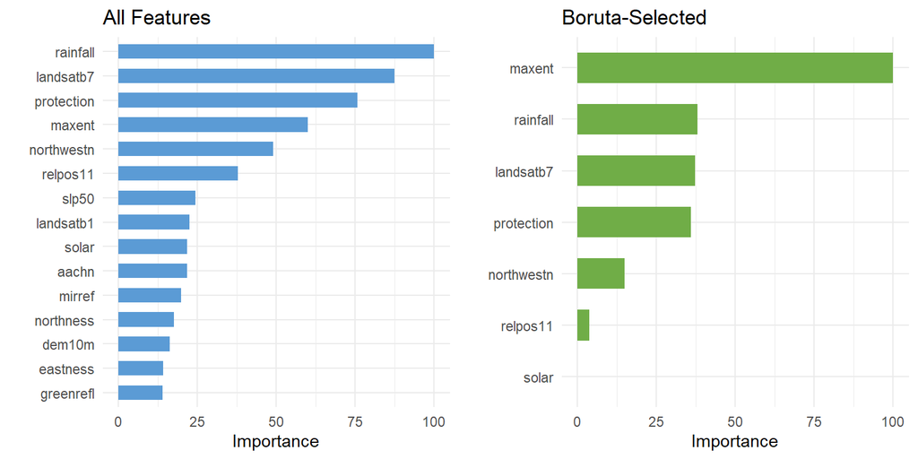

```r
# Variable importance comparison
p_full <- vip::vip(dep_tr_full, num_features = 15,
                   aesthetics = list(fill = "#5b9bd5", width = 0.6)) +
  ggtitle("All Features") + theme_minimal(base_size = 11)

p_bor  <- vip::vip(dep_tr_bor,  num_features = 15,
                   aesthetics = list(fill = "#70ad47", width = 0.6)) +
  ggtitle("Boruta-Selected") + theme_minimal(base_size = 11)

gridExtra::grid.arrange(p_full, p_bor, ncol = 2)
```

> **Application:** Permutation importance provides a data-driven quantification of soil forming factors. If precipitation (`rainfall`) dominates, your model confirms climate-controlled SOC dynamics in this MLRA. Document the top-ranked covariates in your MLRA correlation documents as quantitative support for your conceptual soil-landscape model.

> **Questions:**  
> 1. Did feature selection (Boruta) improve or worsen CV RMSE?  
> 2. Which predictor has the highest permutation importance?  
> 3. How does this top predictor relate to the soil-forming factors for O horizon development in WV?

# 8 Part 7 — Partial Dependence Plots

## 8.1 Theory: What PDPs Show

A **Partial Dependence Plot (PDP)** marginalizes the model’s predictions over all other features to show the average effect of a single predictor:

$$\hat{f}_{x_j}(x_j) = \frac{1}{N}
\sum_{i=1}^{N} \hat{f}(x_j, \mathbf{x}_{-j,i})$$

Unlike variable importance (which ranks features), PDPs show the *shape* of the relationship — whether it is linear, threshold-driven, or non-monotonic. This is especially useful for communicating soil-landscape relationships to field scientists.

## 8.2 Fit Final Model and Plot

```r
# Refit using CV-tuned hyperparameters from dep_tr_bor (Part 6)
# dep_tr_bor searched mtry, min.node.size, and splitrule via 10-fold CV —
# hardcoding heuristics here would give worse OOB R² than the CV result.
cat("Best hyperparameters from CV (dep_tr_bor):\n")
```

```
#> Best hyperparameters from CV (dep_tr_bor):
```

```r
print(dep_tr_bor$bestTune)
```

```
#>   mtry  splitrule min.node.size
#> 2    2 extratrees             5
```

```r
# Guard: bestTune$mtry must not exceed the number of confirmed features.
# A stale cv-boruta cache (trained on a larger feature set) can produce an
# mtry value that is valid for the cached run but too large here.
mtry_final <- min(dep_tr_bor$bestTune$mtry, length(vars_confirmed))
if (mtry_final != dep_tr_bor$bestTune$mtry)
  warning("bestTune$mtry clamped to ", mtry_final,
          " — re-knit with cache cleared to resolve cache inconsistency.")

set.seed(42)
rf_final <- ranger(
  formula       = as.formula(paste(yvar, "~", paste(vars_confirmed, collapse = " + "))),
  data          = soildata[, c(yvar, vars_confirmed)],
  num.trees     = 500,
  mtry          = mtry_final,
  min.node.size = dep_tr_bor$bestTune$min.node.size,
  splitrule     = dep_tr_bor$bestTune$splitrule,
  importance    = "permutation"
)

cat(sprintf("OOB R2:   %.4f\n", rf_final$r.squared))
```

```
#> OOB R2:   0.3095
```

```r
cat(sprintf("OOB RMSE: %.4f cm\n", sqrt(rf_final$prediction.error)))
```

```
#> OOB RMSE: 4.9929 cm
```

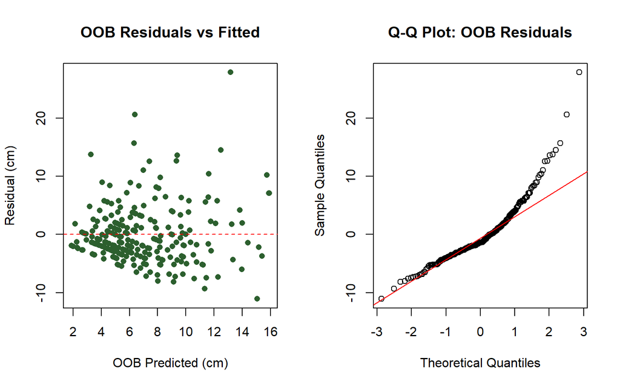

```r
# ── OOB residual diagnostics  ─────────────────────────────
oob_preds  <- rf_final$predictions          # OOB predictions in cm
resid_oob  <- soildata[[yvar]] - oob_preds

par(mfrow = c(1, 2))
plot(oob_preds, resid_oob,
     xlab = "OOB Predicted (cm)", ylab = "Residual (cm)",
     main = "OOB Residuals vs Fitted", pch = 16, col = "#2c5f2e")
abline(h = 0, col = "red", lty = 2)
qqnorm(resid_oob, main = "Q-Q Plot: OOB Residuals")
qqline(resid_oob, col = "red")
```

```r
par(mfrow = c(1, 1))

oob_rmse <- sqrt(mean(resid_oob^2))
oob_r2   <- 1 - sum(resid_oob^2) / sum((soildata[[yvar]] - mean(soildata[[yvar]]))^2)
cat("OOB RMSE (cm):", round(oob_rmse, 2), "\n")
```

```
#> OOB RMSE (cm): 4.99
```

```r
cat("OOB R\u00b2:      ", round(oob_r2, 3), "\n")
```

```
#> OOB R²:       0.307
```

```r
# Top 2 predictors from importance
top_vars <- names(sort(rf_final$variable.importance, decreasing = TRUE))[1:2]
cat("Top predictors:", paste(top_vars, collapse = ", "), "\n")
```

```
#> Top predictors: maxent, landsatb7
```

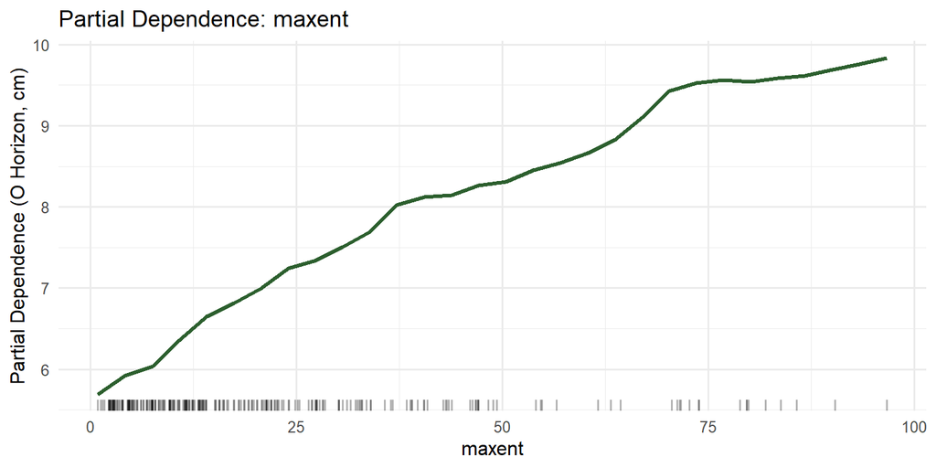

```r
# PDP for top two predictors
pdp1 <- pdp::partial(rf_final, pred.var = top_vars[1],
                     plot = FALSE, grid.resolution = 30)
pdp2 <- pdp::partial(rf_final, pred.var = top_vars[2],
                     plot = FALSE, grid.resolution = 30)


ggplot(pdp1, aes_string(x = top_vars[1], y = "yhat")) +
  geom_line(color = "#2c5f2e", linewidth = 1.2) +
  geom_rug(data = soildata, aes_string(x = top_vars[1], y = NULL),
           sides = "b", alpha = 0.3) +
  labs(x = top_vars[1], y = "Partial Dependence (O Horizon, cm)",
       title = paste("Partial Dependence:", top_vars[1])) +
  theme_minimal(base_size = 12)
```

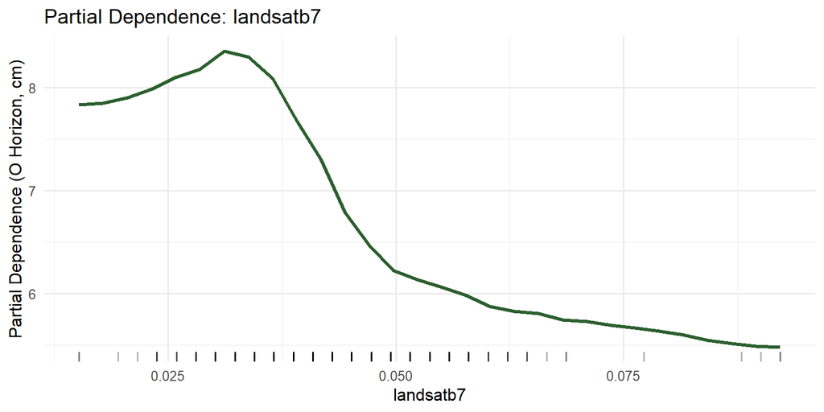

```r
ggplot(pdp2, aes_string(x = top_vars[2], y = "yhat")) +
  geom_line(color = "#2c5f2e", linewidth = 1.2) +
  geom_rug(data = soildata, aes_string(x = top_vars[2], y = NULL),
           sides = "b", alpha = 0.3) +
  labs(x = top_vars[2], y = "Partial Dependence (O Horizon, cm)",
       title = paste("Partial Dependence:", top_vars[2])) +
  theme_minimal(base_size = 12)
```

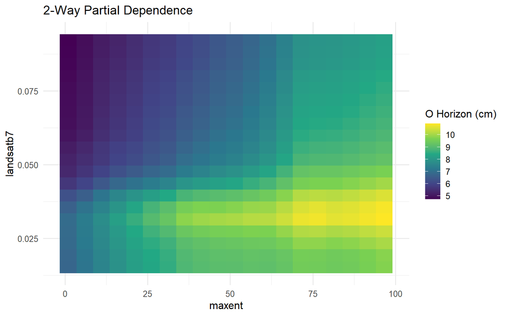

```r
pd_2way <- pdp::partial(
  rf_final,
  pred.var        = top_vars[1:2],
  plot            = FALSE,
  grid.resolution = 20
)

ggplot(pd_2way, aes_string(x = top_vars[1], y = top_vars[2], fill = "yhat")) +
  geom_tile() +
  scale_fill_viridis_c(name = "O Horizon (cm)", option = "D") +
  labs(title = "2-Way Partial Dependence", x = top_vars[1], y = top_vars[2]) +
  theme_minimal(base_size = 12)
```

> **Questions:**  
> 1. What is the shape of the top predictor’s partial dependence — linear, threshold, or non-monotonic? What soil-forming factor does this suggest?  
> 2. In the 2-way plot, do the two predictors interact (non-parallel isolines) or act independently (parallel bands)?  
> 3. At what value of the top predictor does O horizon thickness increase most steeply? Does this correspond to a known ecological or pedological threshold in WV?

# 9 Part 8 — Model Diagnostics

## 9.1 Observed vs. Predicted

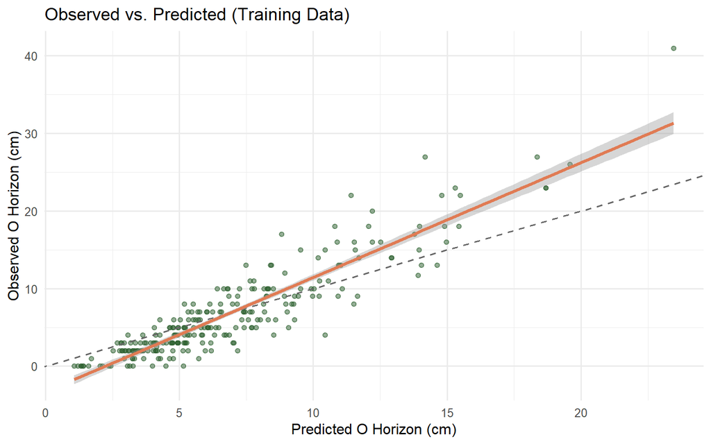

```r
# Generate training predictions
soildata$pred_Otot <- predict(rf_final, data = soildata)$predictions
soildata$resid     <- soildata$Otot - soildata$pred_Otot

# 1:1 plot
ggplot(soildata, aes(x = pred_Otot, y = Otot)) +
  geom_point(alpha = 0.5, color = "#2c5f2e") +
  geom_abline(linetype = "dashed", color = "gray40") +
  geom_smooth(method = "lm", color = "#e07b54", se = TRUE) +
  labs(x = "Predicted O Horizon (cm)",
       y = "Observed O Horizon (cm)",
       title = "Observed vs. Predicted (Training Data)") +
  theme_minimal(base_size = 12)
```

## 9.2 Residual Plots

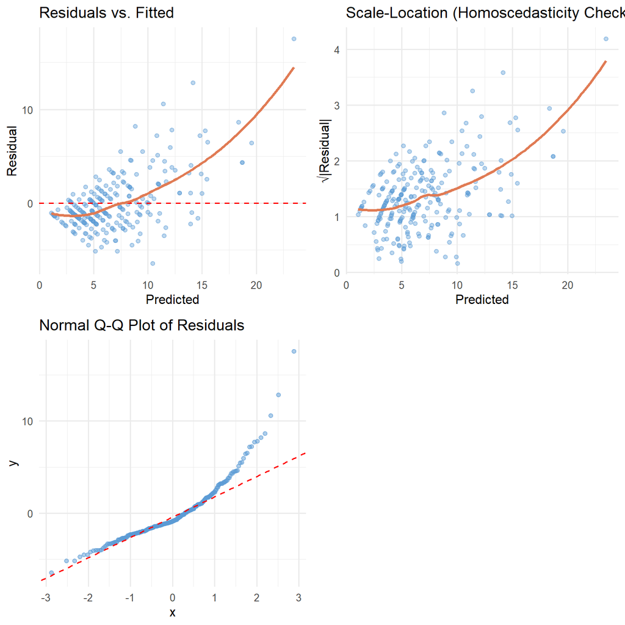

```r
p_res1 <- ggplot(soildata, aes(x = pred_Otot, y = resid)) +
  geom_point(alpha = 0.4, color = "#5b9bd5") +
  geom_hline(yintercept = 0, color = "red", linetype = "dashed") +
  geom_smooth(se = FALSE, color = "#e07b54") +
  labs(x = "Predicted", y = "Residual",
       title = "Residuals vs. Fitted") +
  theme_minimal(base_size = 12)

p_res2 <- ggplot(soildata, aes(x = pred_Otot, y = sqrt(abs(resid)))) +
  geom_point(alpha = 0.4, color = "#5b9bd5") +
  geom_smooth(se = FALSE, color = "#e07b54") +
  labs(x = "Predicted", y = "√|Residual|",
       title = "Scale-Location (Homoscedasticity Check)") +
  theme_minimal(base_size = 12)

p_res3 <- ggplot(soildata, aes(sample = resid)) +
  geom_qq(alpha = 0.5, color = "#5b9bd5") +
  geom_qq_line(color = "red", linetype = "dashed") +
  labs(title = "Normal Q-Q Plot of Residuals") +
  theme_minimal(base_size = 12)

gridExtra::grid.arrange(p_res1, p_res2, p_res3, ncol = 2)
```

> **Interpreting diagnostics:**  
> - **Residuals vs Fitted:** Should show random scatter around zero. Systematic patterns indicate model misfit.  
> - **Scale-Location:** A flat line indicates homoscedasticity (equal variance). Increasing spread suggests heteroscedasticity.  
> - **Q-Q Plot:** Points should follow the reference line. Deviations in the tails indicate non-normal residuals, which can affect prediction intervals.

# 10 Part 9 — SHAP Analysis

## 10.1 Theory: Why SHAP?

Permutation importance and PDPs answer *which* variables matter and their *average* effect. SHAP (SHapley Additive exPlanations, Lundberg & Lee 2017) goes further — it attributes each prediction to individual feature contributions for **every observation**, not just on average across the dataset.

**The SHAP decomposition:**
$$\hat{f}(x_i) = \phi_0 + \sum_{j=1}^{p}
\phi_{ij}$$

where $\phi_0$ is the global baseline (mean prediction) and $\phi_{ij}$ is the contribution of feature $j$ to observation $i$’s prediction. These values are derived from cooperative game theory: each feature’s contribution is its average marginal contribution across all possible orderings of features entering the model.

**Why SHAP matters for DSM:**

| Tool | What it shows | Limitation |
| --- | --- | --- |
| Permutation VIP | Global ranking only | No per-observation detail |
| PDP | Average marginal effect | Masks heterogeneity |
| SHAP | Per-observation direction + magnitude | Computationally intensive |

## 10.2 Setup: Prepare the SHAP Model

```r
# Install if needed: install.packages(c("fastshap", "shapviz"))
library(fastshap)
library(shapviz)

# ── Ensure the final model exists in environment ──────────────────────────
# (rf_final from Part 10 must be in the environment, trained on Otot)
# If re-running standalone, recreate it here:

soildata_nohist <- droplevels(subset(
  read.csv("soildata.csv"), order != "histosol"
))

predictors <- c(
  "rainfall",   "geology",    "aachn",      "dem10m",     "downslpgra",
  "eastness",   "greenrefl",  "landsatb1",  "landsatb2",  "landsatb3",
  "landsatb7",  "maxc100",    "maxent",     "minc100",    "mirref",
  "ndvi",       "northeastn", "northness",  "northwestn", "planc100",
  "proc100",    "protection", "relpos11",   "slp50",      "solar",
  "tanc75"
)

set.seed(42)
rf_shap <- ranger(
  formula       = Otot ~ .,
  data          = soildata_nohist[, c("Otot", predictors)],
  num.trees     = 500,
  mtry          = dep_tr_bor$bestTune$mtry,
  min.node.size = dep_tr_bor$bestTune$min.node.size,
  splitrule     = dep_tr_bor$bestTune$splitrule,
  importance    = "permutation",
  seed          = 42
)

cat(sprintf("OOB R\u00b2:   %.3f\n", rf_shap$r.squared))
```

```
#> OOB R²:   0.256
```

```r
cat(sprintf("OOB RMSE (cm): %.2f\n", sqrt(rf_shap$prediction.error)))
```

```
#> OOB RMSE (cm): 4.84
```

## 10.3 Compute SHAP Values

```r
# ── Prediction wrapper required by fastshap ────────────────────────────────
pfun <- function(object, newdata) {
  predict(object, data = newdata)$predictions
}

# ── Monte Carlo SHAP approximation ─────────────────────────────────────────
# nsim = 100 gives stable estimates; increase to 200 for final analysis
# This takes ~30–60 seconds depending on hardware
set.seed(42)
shap_vals <- fastshap::explain(
  object        = rf_shap,
  X             = soildata_nohist[, predictors],
  pred_wrapper  = pfun,
  nsim          = 100
)

# shap_vals is an nsample × nfeature matrix (cm units)
dim(shap_vals)
```

```
#> [1] 249  26
```

```r
head(round(shap_vals[, 1:6], 4))
```

```
#>      rainfall geology   aachn  dem10m downslpgra eastness
#> [1,]   0.2909 -0.0436 -0.0339 -0.0519     0.0130   0.0283
#> [2,]   0.2499 -0.0773 -0.1559  0.2496     0.0262  -0.3680
#> [3,]   0.1690 -0.0588  0.2041  0.0222     0.0103  -0.4511
#> [4,]   0.3384  0.0049  0.0177  0.3276     0.0667  -0.5240
#> [5,]   0.4605  0.0519  0.0223  0.2730     0.1087   0.2033
#> [6,]   0.2719 -0.0897 -0.0887  0.1460     0.0097  -0.0643
```

## 10.4 Global Importance (Mean |SHAP|)

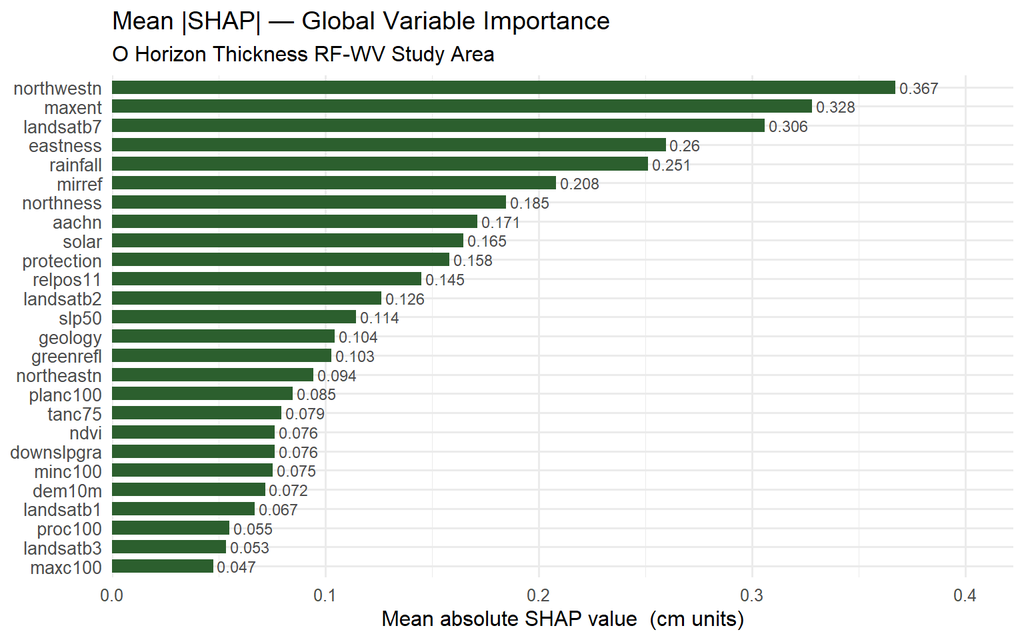

```r
# Mean absolute SHAP = global variable importance (model-agnostic, unbiased)
mean_abs_shap <- colMeans(abs(shap_vals)) |>
  sort(decreasing = TRUE) |>
  (\(x) data.frame(
    feature        = factor(names(x), levels = rev(names(x))),
    mean_abs_shap  = x
  ))()

ggplot(mean_abs_shap, aes(x = mean_abs_shap, y = feature)) +
  geom_col(fill = "#2c5f2e", width = 0.7) +
  geom_text(aes(label = round(mean_abs_shap, 3)),
            hjust = -0.1, size = 3.2, color = "gray30") +
  scale_x_continuous(expand = expansion(mult = c(0, 0.15))) +
  labs(
    title    = "Mean |SHAP| — Global Variable Importance",
    subtitle = "O Horizon Thickness RF-WV Study Area",
    x        = "Mean absolute SHAP value  (cm units)",
    y        = NULL
  ) +
  theme_minimal(base_size = 12) +
  theme(axis.text.y = element_text(size = 10))
```

## 10.5 Beeswarm Plot: Direction and Magnitude

The beeswarm (SHAP summary) plot simultaneously shows importance (x-axis spread), direction (positive = increases prediction), and feature value (colour) for every observation. This is the single most informative diagnostic plot in an interpretable ML workflow.

```r
# Build long-format data frame for ggplot beeswarm
X_mat <- as.data.frame(soildata_nohist[, predictors])

# Normalise each feature to [0, 1] for colour mapping
numeric_cols <- names(X_mat)[sapply(X_mat, is.numeric)]

X_norm <- as.data.frame(lapply(X_mat[, numeric_cols, drop = FALSE], function(v) {
  rng <- range(v, na.rm = TRUE)
  if (diff(rng) == 0) return(rep(0.5, length(v)))
  (v - rng[1]) / diff(rng)
}))

# Add geology back as numeric (integer codes) so join has no NULLs
X_norm_full <- X_norm
if ("geology" %in% colnames(X_mat)) {
  X_norm_full$geology <- as.numeric(as.factor(X_mat$geology))
  # re-normalise to 0-1
  rng <- range(X_norm_full$geology, na.rm = TRUE)
  X_norm_full$geology <- (X_norm_full$geology - rng[1]) / diff(rng)
}

# Rebuild shap_long with X_norm_full
shap_long <- as.data.frame(shap_vals) |>
  tibble::rowid_to_column("obs") |>
  tidyr::pivot_longer(-obs, names_to = "feature", values_to = "shap") |>
  dplyr::left_join(
    X_norm_full |>
      tibble::rowid_to_column("obs") |>
      tidyr::pivot_longer(-obs, names_to = "feature", values_to = "feat_norm") |>
      dplyr::mutate(feat_norm = as.numeric(feat_norm)),
    by = c("obs", "feature")
  ) |>
  dplyr::mutate(
    feat_norm = as.numeric(feat_norm),
    feature   = factor(feature,
                       levels = rev(levels(mean_abs_shap$feature)))
  )

# Verify
str(shap_long$feat_norm)
```

```
#>  num [1:6474] 0.3333 0 0.1901 0.6649 0.0678 ...
```

```r
sum(is.na(shap_long$feat_norm))
```

```
#> [1] 0
```

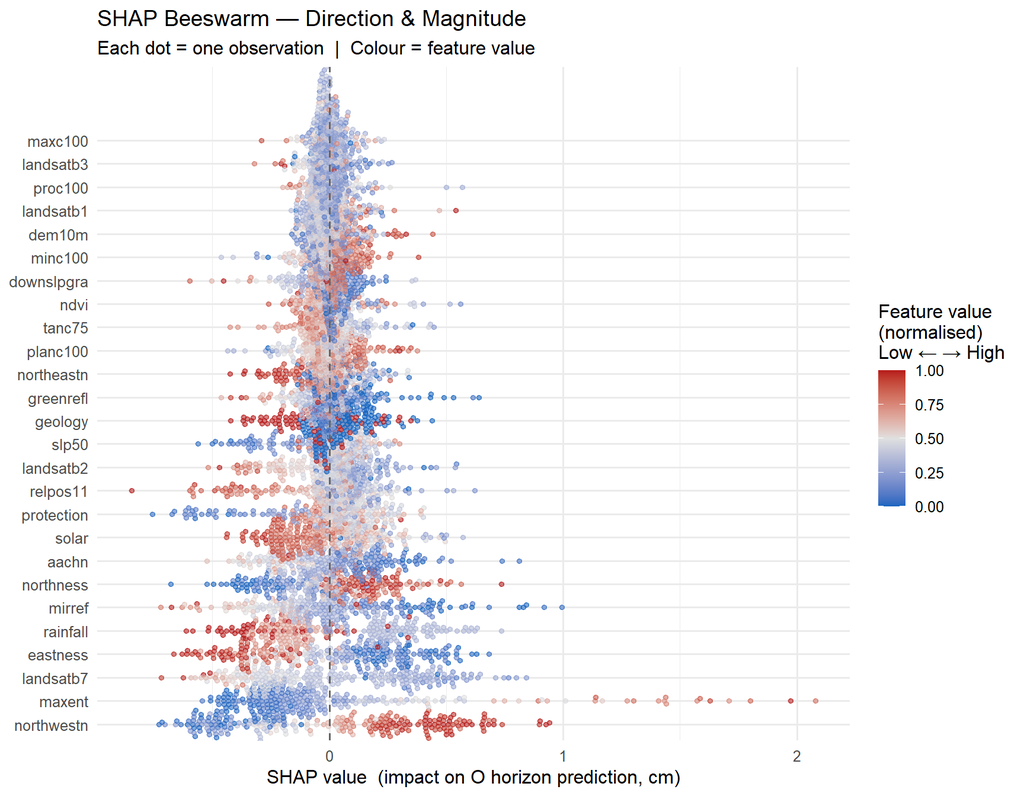

```r
ggplot(shap_long, aes(x = shap, y = feature, colour = feat_norm)) +
  ggbeeswarm::geom_beeswarm(
    groupOnX    = FALSE,
    size        = 1.2,
    alpha       = 0.55,
    cex         = 0.6
  ) +
  scale_colour_gradient2(
    low      = "#1565C0",
    mid      = "#E0E0E0",
    high     = "#B71C1C",
    midpoint = 0.5,
    name     = "Feature value\n(normalised)\nLow ← → High"
  ) +
  geom_vline(xintercept = 0, colour = "grey40", linetype = "dashed") +
  labs(
    title    = "SHAP Beeswarm — Direction & Magnitude",
    subtitle = "Each dot = one observation  |  Colour = feature value",
    x        = "SHAP value  (impact on O horizon prediction, cm)",
    y        = NULL
  ) +
  theme_minimal(base_size = 12) +
  theme(legend.position = "right")
```

> **How to read this plot:**
> - **Horizontal position** = how much this feature pushed the prediction up (right) or down (left) for each observation.
> - **Colour** = the feature’s actual value for that observation (red = high, blue = low).
> - **Width of the cloud** = overall importance of the feature (same ranking as Mean |SHAP|).
> - **Pedological check:** For a well-specified DSM model you expect:
>   - `maxent` red dots on the right (high terrain complexity → topographically protected positions → thick O horizons)
>   - `solar` red dots on the left (high solar = warm dry sites → thin O horizons)
>   - `northwestn` / `northness` red dots on the right (cool NW-facing aspects → reduced insolation, slower decomposition → thicker O)

## 10.6 SHAP Dependence Plots

A SHAP dependence plot shows one feature’s SHAP values against its actual values. The colour encodes a second feature, revealing interaction effects.

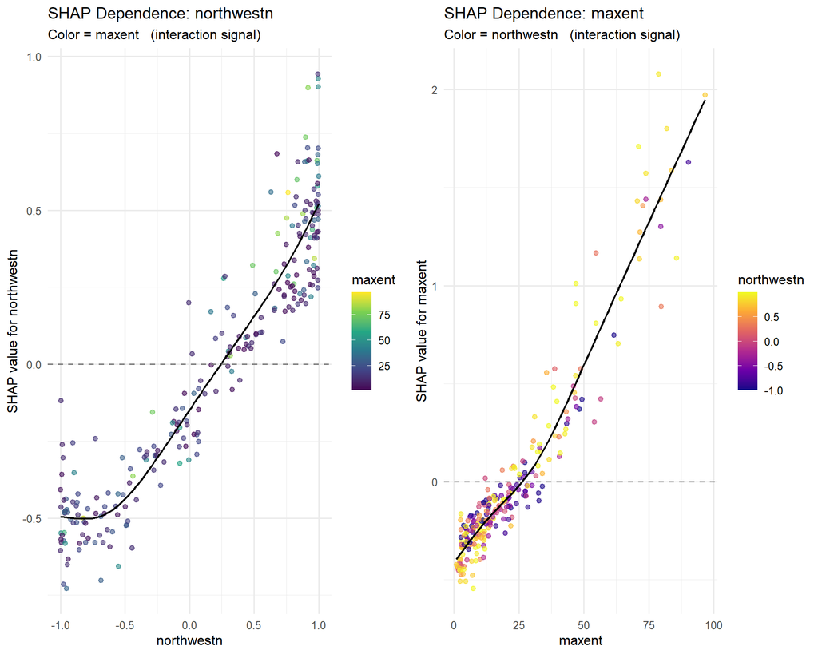

```r
# Get top 2 features by mean |SHAP| for the plot
top2 <- as.character(mean_abs_shap$feature[1:2])
f1   <- top2[1]
f2   <- top2[2]

# Build dependence data: feature 1 SHAP vs feature 1 value, colored by feature 2
dep_df <- data.frame(
  x_val   = X_mat[[f1]],
  shap_f1 = shap_vals[, f1],    # matrix column indexing
  col_var = X_mat[[f2]]
)

p_dep1 <- ggplot(dep_df, aes(x = x_val, y = shap_f1, colour = col_var)) +
  geom_point(alpha = 0.6, size = 1.8) +
  geom_smooth(method = "gam", formula = y ~ s(x, bs = "cs"),
              colour = "black", se = FALSE, linewidth = 0.8) +
  scale_colour_viridis_c(name = f2, option = "D") +
  geom_hline(yintercept = 0, linetype = "dashed", colour = "grey50") +
  labs(
    title    = paste("SHAP Dependence:", f1),
    subtitle = paste("Color =", f2, "  (interaction signal)"),
    x        = f1,
    y        = paste("SHAP value for", f1)
  ) +
  theme_minimal(base_size = 12)

# Second dependence plot: feature 2
dep_df2 <- data.frame(
  x_val   = X_mat[[f2]],
  shap_f2 = shap_vals[, f2],    # matrix column indexing
  col_var = X_mat[[f1]]
)

p_dep2 <- ggplot(dep_df2, aes(x = x_val, y = shap_f2, colour = col_var)) +
  geom_point(alpha = 0.6, size = 1.8) +
  geom_smooth(method = "gam", formula = y ~ s(x, bs = "cs"),
              colour = "black", se = FALSE, linewidth = 0.8) +
  scale_colour_viridis_c(name = f1, option = "C") +
  geom_hline(yintercept = 0, linetype = "dashed", colour = "grey50") +
  labs(
    title    = paste("SHAP Dependence:", f2),
    subtitle = paste("Color =", f1, "  (interaction signal)"),
    x        = f2,
    y        = paste("SHAP value for", f2)
  ) +
  theme_minimal(base_size = 12)

gridExtra::grid.arrange(p_dep1, p_dep2, ncol = 2)
```

> **Interaction signal:** If the colours in a dependence plot form a gradient pattern (e.g., red points cluster in the upper-right), the effect of feature 1 on the prediction *depends on* the value of feature 2 — a true interaction. This is information PDPs cannot show because they average across that heterogeneity.

**Interpretation:** The left panel shows northwestn has a clean, independent effect on O horizon thickness — SHAP values rise monotonically from −0.5 cm (SE-facing) to +1.0 cm (NW-facing) with no colour gradient, confirming aspect operates additively regardless of terrain complexity. The right panel reveals a one-directional interaction: maxent’s contribution to O horizon thickness is amplified on NW-facing slopes (yellow dots consistently above the smooth) but suppressed on SE-facing slopes (purple dots below). The bottom-left cluster of yellow dots at low maxent confirms that NW aspect alone — without topographic complexity — adds little through the maxent pathway. Together the panels describe a coherent soil-landscape mechanism: cool NW-facing aspects and dissected terrain independently favour organic matter accumulation, but their combination produces the thickest O horizons in the dataset.